# Census Corrections

When trying to use census tracts, I realized that there were some census tracts that were mislabelled with the wrong Bairro IBGE code, and the wrong Bairro name. This was affecting the aggregation at the bairro level, such that some neighborhoods like Manuel Dias Branco had 3000 people missing who had been aggregated to Praia do Futuro II. Moreover, since the census happened, the new neighborhoods of Boa Vista, Olavo Oliveira and Parque Santa Maria were created. These also have to be assigned the right census tracts.

Thus I checked all census tracts to make sure they were being aggregated at the the right neighborhood. Based on this I made a correction table, the details of which are described here.

At the end there is a comparison of old and new population totals before and after correction.

##### 1. Vila Ellery in Alvaro Weyne

[figure not shown]

Vila Ellery in Alvaro Weyne

Old data

| ID | CD_GEOCODI | CD_GEOCODB | NM_BAIRRO | CD_GEOCODS | NM_SUBDIST | CD_GEOCODD | NM_DISTRIT | CD_GEOCODM | NM_MUNICIP | NM_MICRO | NM_MESO |
| --- | --- | --- | --- | --- | --- | --- | --- | --- | --- | --- | --- |
| 12868 | 230440005070949 | 230440005038 | Vila Ellery | 23044000507 | BARRA DO CEARA | 230440005 | FORTALEZA | 2304400 | FORTALEZA | FORTALEZA | METROPOLITANA DE FORTALEZA |

Corrected data

| ID | CD_GEOCODI | CD_GEOCODB_NEW | NM_BAIRRO_NEW | CD_GEOCODS_NEW | NM_SUBDIST_NEW | CD_GEOCODD_NEW | NM_DISTRIT_NEW | CD_GEOCODM_NEW | NM_MUNICIP_NEW | NM_MICRO_NEW | NM_MESO_NEW |
| --- | --- | --- | --- | --- | --- | --- | --- | --- | --- | --- | --- |
| 12868 | 230440005070949 | 230440005003 | Alvaro Weyne | 23044000507 | BARRA DO CEARA | 230440005 | FORTALEZA | 2304400 | FORTALEZA | FORTALEZA | METROPOLITANA DE FORTALEZA |

##### 2. Varjota and De Loudres in Papicu

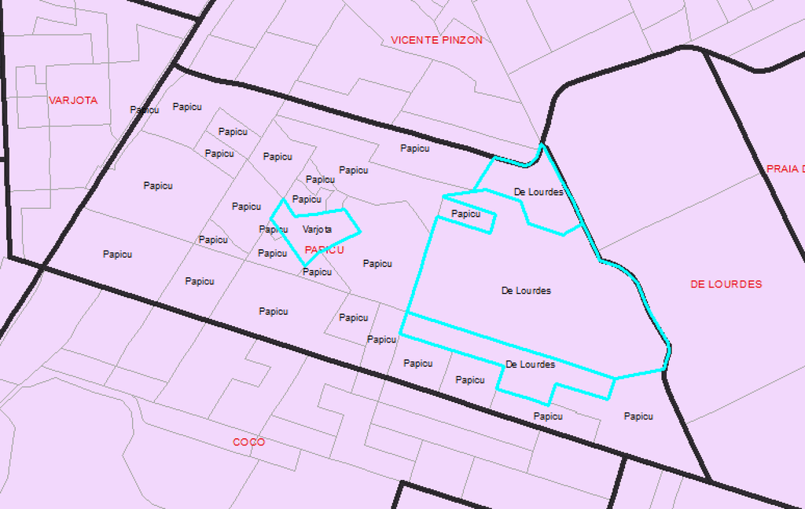

Varjota and De Loudres in Papicu

Old data

| ID | CD_GEOCODI | CD_GEOCODB | NM_BAIRRO | CD_GEOCODS | NM_SUBDIST | CD_GEOCODD | NM_DISTRIT | CD_GEOCODM | NM_MUNICIP | NM_MICRO | NM_MESO |
| --- | --- | --- | --- | --- | --- | --- | --- | --- | --- | --- | --- |
| 13531 | 230440005121095 | 230440005036 | Varjota | 23044000512 | MUCURIPE | 230440005 | FORTALEZA | 2304400 | FORTALEZA | FORTALEZA | METROPOLITANA DE FORTALEZA |
| 13359 | 230440005120414 | 230440005115 | De Lourdes | 23044000512 | MUCURIPE | 230440005 | FORTALEZA | 2304400 | FORTALEZA | FORTALEZA | METROPOLITANA DE FORTALEZA |
| 13349 | 230440005120404 | 230440005115 | De Lourdes | 23044000512 | MUCURIPE | 230440005 | FORTALEZA | 2304400 | FORTALEZA | FORTALEZA | METROPOLITANA DE FORTALEZA |
| 13348 | 230440005120403 | 230440005115 | De Lourdes | 23044000512 | MUCURIPE | 230440005 | FORTALEZA | 2304400 | FORTALEZA | FORTALEZA | METROPOLITANA DE FORTALEZA |

Corrected data

| ID | CD_GEOCODI | CD_GEOCODB_NEW | NM_BAIRRO_NEW | CD_GEOCODS_NEW | NM_SUBDIST_NEW | CD_GEOCODD_NEW | NM_DISTRIT_NEW | CD_GEOCODM_NEW | NM_MUNICIP_NEW | NM_MICRO_NEW | NM_MESO_NEW |
| --- | --- | --- | --- | --- | --- | --- | --- | --- | --- | --- | --- |
| 13531 | 230440005121095 | 230440005027 | Papicu | 23044000512 | MUCURIPE | 230440005 | FORTALEZA | 2304400 | FORTALEZA | FORTALEZA | METROPOLITANA DE FORTALEZA |
| 13359 | 230440005120414 | 230440005027 | Papicu | 23044000512 | MUCURIPE | 230440005 | FORTALEZA | 2304400 | FORTALEZA | FORTALEZA | METROPOLITANA DE FORTALEZA |
| 13349 | 230440005120404 | 230440005027 | Papicu | 23044000512 | MUCURIPE | 230440005 | FORTALEZA | 2304400 | FORTALEZA | FORTALEZA | METROPOLITANA DE FORTALEZA |
| 13348 | 230440005120403 | 230440005027 | Papicu | 23044000512 | MUCURIPE | 230440005 | FORTALEZA | 2304400 | FORTALEZA | FORTALEZA | METROPOLITANA DE FORTALEZA |

##### 3. Varjota in Meireles

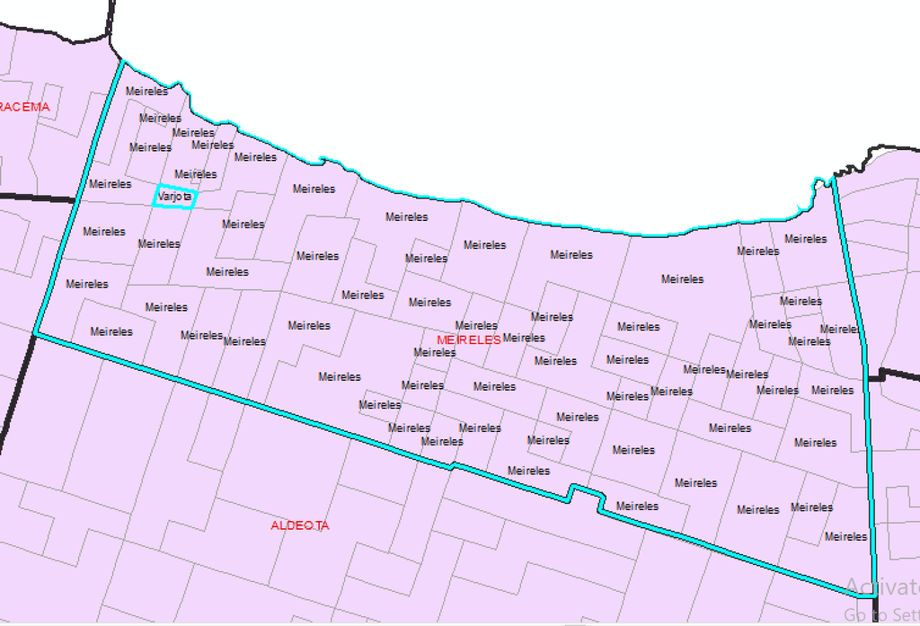

Varjota in Meireles

Old data

| ID | CD_GEOCODI | CD_GEOCODB | NM_BAIRRO | CD_GEOCODS | NM_SUBDIST | CD_GEOCODD | NM_DISTRIT | CD_GEOCODM | NM_MUNICIP | NM_MICRO | NM_MESO |
| --- | --- | --- | --- | --- | --- | --- | --- | --- | --- | --- | --- |
| 13530 | 230440005121094 | 230440005036 | Varjota | 23044000512 | MUCURIPE | 230440005 | FORTALEZA | 2304400 | FORTALEZA | FORTALEZA | METROPOLITANA DE FORTALEZA |

Corrected data

| ID | CD_GEOCODI | CD_GEOCODB_NEW | NM_BAIRRO_NEW | CD_GEOCODS_NEW | NM_SUBDIST_NEW | CD_GEOCODD_NEW | NM_DISTRIT_NEW | CD_GEOCODM_NEW | NM_MUNICIP_NEW | NM_MICRO_NEW | NM_MESO_NEW |
| --- | --- | --- | --- | --- | --- | --- | --- | --- | --- | --- | --- |
| 13530 | 230440005121094 | 230440005024 | Meireles | 23044000512 | MUCURIPE | 230440005 | FORTALEZA | 2304400 | FORTALEZA | FORTALEZA | METROPOLITANA DE FORTALEZA |

##### 4. Parreo in Sao Joao do Taupe

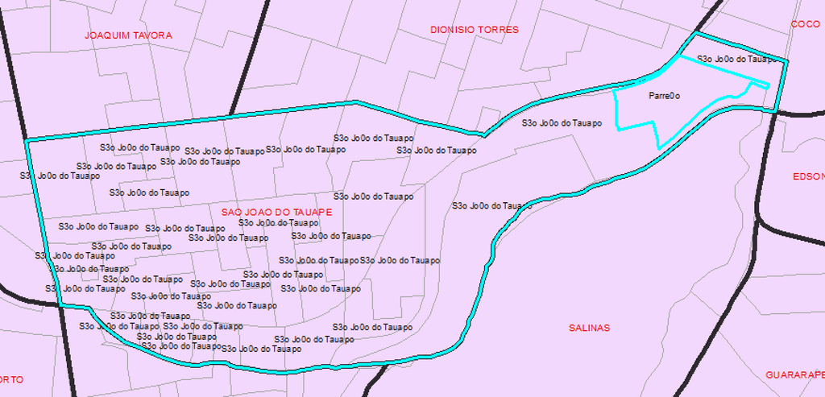

Parreo in Sao Joao do Taupe

Old data

| ID | CD_GEOCODI | CD_GEOCODB | NM_BAIRRO | CD_GEOCODS | NM_SUBDIST | CD_GEOCODD | NM_DISTRIT | CD_GEOCODM | NM_MUNICIP | NM_MICRO | NM_MESO |
| --- | --- | --- | --- | --- | --- | --- | --- | --- | --- | --- | --- |
| 13255 | 230440005081034 | 230440005030 | Parreo | 23044000508 | CENTRO | 230440005 | FORTALEZA | 2304400 | FORTALEZA | FORTALEZA | METROPOLITANA DE FORTALEZA |

Corrected data

| ID | CD_GEOCODI | CD_GEOCODB_NEW | NM_BAIRRO_NEW | CD_GEOCODS_NEW | NM_SUBDIST_NEW | CD_GEOCODD_NEW | NM_DISTRIT_NEW | CD_GEOCODM_NEW | NM_MUNICIP_NEW | NM_MICRO_NEW | NM_MESO_NEW |
| --- | --- | --- | --- | --- | --- | --- | --- | --- | --- | --- | --- |
| 13255 | 230440005081034 | 230440005035 | Sao Joao do Taupe | 23044000508 | CENTRO | 230440005 | FORTALEZA | 2304400 | FORTALEZA | FORTALEZA | METROPOLITANA DE FORTALEZA |

##### 5. Praia do Futuro II in Manuel Dias Branco

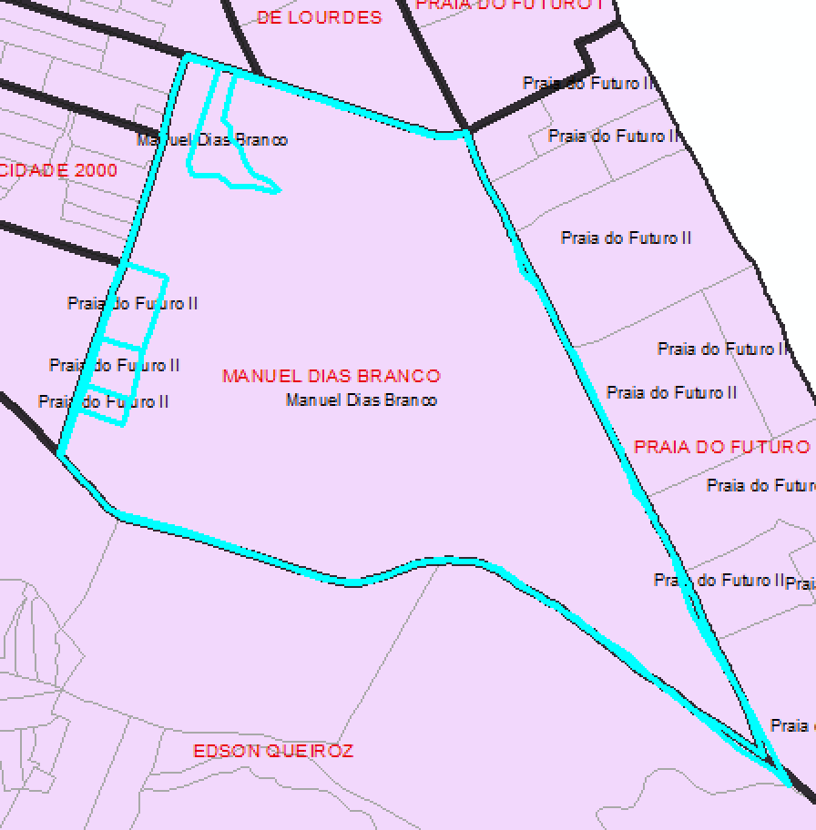

Praia do Futuro II in Manuel Dias Branco

Old data

| ID | CD_GEOCODI | CD_GEOCODB | NM_BAIRRO | CD_GEOCODS | NM_SUBDIST | CD_GEOCODD | NM_DISTRIT | CD_GEOCODM | NM_MUNICIP | NM_MICRO | NM_MESO |
| --- | --- | --- | --- | --- | --- | --- | --- | --- | --- | --- | --- |
| 13554 | 230440005121118 | 230440005114 | Praia do Futuro II | 23044000512 | MUCURIPE | 230440005 | FORTALEZA | 2304400 | FORTALEZA | FORTALEZA | METROPOLITANA DE FORTALEZA |
| 13595 | 230440005121159 | 230440005114 | Praia do Futuro II | 23044000512 | MUCURIPE | 230440005 | FORTALEZA | 2304400 | FORTALEZA | FORTALEZA | METROPOLITANA DE FORTALEZA |
| 13596 | 230440005121160 | 230440005114 | Praia do Futuro II | 23044000512 | MUCURIPE | 230440005 | FORTALEZA | 2304400 | FORTALEZA | FORTALEZA | METROPOLITANA DE FORTALEZA |

Corrected data

| ID | CD_GEOCODI | CD_GEOCODB_NEW | NM_BAIRRO_NEW | CD_GEOCODS_NEW | NM_SUBDIST_NEW | CD_GEOCODD_NEW | NM_DISTRIT_NEW | CD_GEOCODM_NEW | NM_MUNICIP_NEW | NM_MICRO_NEW | NM_MESO_NEW |
| --- | --- | --- | --- | --- | --- | --- | --- | --- | --- | --- | --- |
| 13554 | 230440005121118 | 230440005112 | Manuel Dias Branco | 23044000512 | MUCURIPE | 230440005 | FORTALEZA | 2304400 | FORTALEZA | FORTALEZA | METROPOLITANA DE FORTALEZA |
| 13595 | 230440005121159 | 230440005112 | Manuel Dias Branco | 23044000512 | MUCURIPE | 230440005 | FORTALEZA | 2304400 | FORTALEZA | FORTALEZA | METROPOLITANA DE FORTALEZA |
| 13596 | 230440005121160 | 230440005112 | Manuel Dias Branco | 23044000512 | MUCURIPE | 230440005 | FORTALEZA | 2304400 | FORTALEZA | FORTALEZA | METROPOLITANA DE FORTALEZA |

##### 6. Praia do Futuro I in Praia do Futuro II

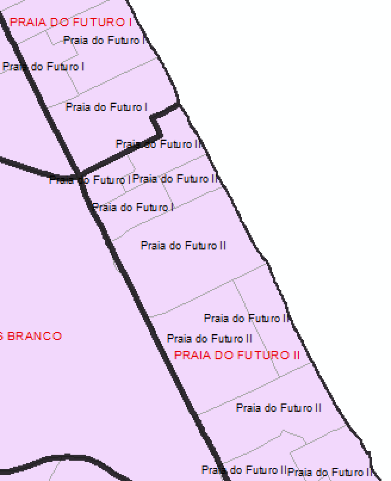

Praia do Futuro I in Praia do Futuro II

Old data

| ID | CD_GEOCODI | CD_GEOCODB | NM_BAIRRO | CD_GEOCODS | NM_SUBDIST | CD_GEOCODD | NM_DISTRIT | CD_GEOCODM | NM_MUNICIP | NM_MICRO | NM_MESO |
| --- | --- | --- | --- | --- | --- | --- | --- | --- | --- | --- | --- |
| 13589 | 230440005121153 | 230440005113 | Praia do Futuro I | 23044000512 | MUCURIPE | 230440005 | FORTALEZA | 2304400 | FORTALEZA | FORTALEZA | METROPOLITANA DE FORTALEZA |
| 13591 | 230440005121155 | 230440005113 | Praia do Futuro I | 23044000512 | MUCURIPE | 230440005 | FORTALEZA | 2304400 | FORTALEZA | FORTALEZA | METROPOLITANA DE FORTALEZA |

Corrected data

| ID | CD_GEOCODI | CD_GEOCODB_NEW | NM_BAIRRO_NEW | CD_GEOCODS_NEW | NM_SUBDIST_NEW | CD_GEOCODD_NEW | NM_DISTRIT_NEW | CD_GEOCODM_NEW | NM_MUNICIP_NEW | NM_MICRO_NEW | NM_MESO_NEW |
| --- | --- | --- | --- | --- | --- | --- | --- | --- | --- | --- | --- |
| 13589 | 230440005121153 | 230440005114 | Praia do Futuro II | 23044000512 | MUCURIPE | 230440005 | FORTALEZA | 2304400 | FORTALEZA | FORTALEZA | METROPOLITANA DE FORTALEZA |
| 13591 | 230440005121155 | 230440005114 | Praia do Futuro II | 23044000512 | MUCURIPE | 230440005 | FORTALEZA | 2304400 | FORTALEZA | FORTALEZA | METROPOLITANA DE FORTALEZA |

##### 7. Gentilandia and Alvaro Weyne in Benfica

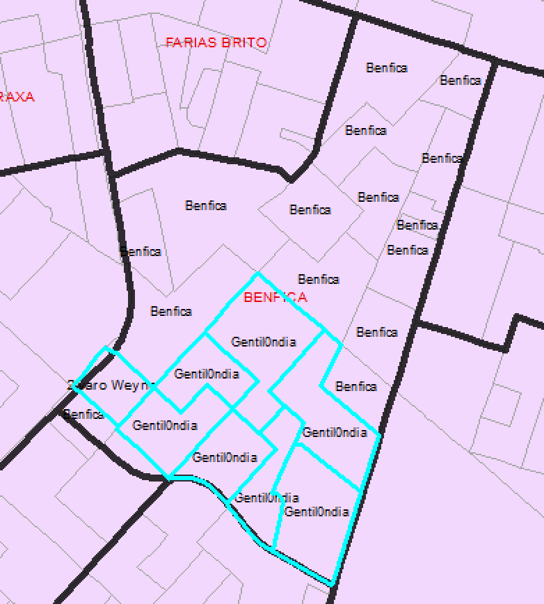

Gentilandia and Alvaro Weyne in Benfica

Old data

| ID | CD_GEOCODI | CD_GEOCODB | NM_BAIRRO | CD_GEOCODS | NM_SUBDIST | CD_GEOCODD | NM_DISTRIT | CD_GEOCODM | NM_MUNICIP | NM_MICRO | NM_MESO |
| --- | --- | --- | --- | --- | --- | --- | --- | --- | --- | --- | --- |
| 12935 | 230440005080020 | 230440005117 | Gentilandia | 23044000508 | CENTRO | 230440005 | FORTALEZA | 2304400 | FORTALEZA | FORTALEZA | METROPOLITANA DE FORTALEZA |
| 12941 | 230440005080026 | 230440005117 | Gentilandia | 23044000508 | CENTRO | 230440005 | FORTALEZA | 2304400 | FORTALEZA | FORTALEZA | METROPOLITANA DE FORTALEZA |
| 12942 | 230440005080027 | 230440005117 | Gentilandia | 23044000508 | CENTRO | 230440005 | FORTALEZA | 2304400 | FORTALEZA | FORTALEZA | METROPOLITANA DE FORTALEZA |
| 12943 | 230440005080028 | 230440005117 | Gentilandia | 23044000508 | CENTRO | 230440005 | FORTALEZA | 2304400 | FORTALEZA | FORTALEZA | METROPOLITANA DE FORTALEZA |
| 13215 | 230440005080873 | 230440005117 | Gentilandia | 23044000508 | CENTRO | 230440005 | FORTALEZA | 2304400 | FORTALEZA | FORTALEZA | METROPOLITANA DE FORTALEZA |
| 13218 | 230440005080997 | 230440005117 | Gentilandia | 23044000508 | CENTRO | 230440005 | FORTALEZA | 2304400 | FORTALEZA | FORTALEZA | METROPOLITANA DE FORTALEZA |
| 13221 | 230440005081000 | 230440005117 | Gentilandia | 23044000508 | CENTRO | 230440005 | FORTALEZA | 2304400 | FORTALEZA | FORTALEZA | METROPOLITANA DE FORTALEZA |
| 13259 | 230440005081162 | 230440005003 | Alvaro Weyne | 23044000508 | CENTRO | 230440005 | FORTALEZA | 2304400 | FORTALEZA | FORTALEZA | METROPOLITANA DE FORTALEZA |

Corrected data

| ID | CD_GEOCODI | CD_GEOCODB_NEW | NM_BAIRRO_NEW | CD_GEOCODS_NEW | NM_SUBDIST_NEW | CD_GEOCODD_NEW | NM_DISTRIT_NEW | CD_GEOCODM_NEW | NM_MUNICIP_NEW | NM_MICRO_NEW | NM_MESO_NEW |
| --- | --- | --- | --- | --- | --- | --- | --- | --- | --- | --- | --- |
| 12935 | 230440005080020 | 230440005007 | Benfica | 23044000508 | CENTRO | 230440005 | FORTALEZA | 2304400 | FORTALEZA | FORTALEZA | METROPOLITANA DE FORTALEZA |
| 12941 | 230440005080026 | 230440005007 | Benfica | 23044000508 | CENTRO | 230440005 | FORTALEZA | 2304400 | FORTALEZA | FORTALEZA | METROPOLITANA DE FORTALEZA |
| 12942 | 230440005080027 | 230440005007 | Benfica | 23044000508 | CENTRO | 230440005 | FORTALEZA | 2304400 | FORTALEZA | FORTALEZA | METROPOLITANA DE FORTALEZA |
| 12943 | 230440005080028 | 230440005007 | Benfica | 23044000508 | CENTRO | 230440005 | FORTALEZA | 2304400 | FORTALEZA | FORTALEZA | METROPOLITANA DE FORTALEZA |
| 13215 | 230440005080873 | 230440005007 | Benfica | 23044000508 | CENTRO | 230440005 | FORTALEZA | 2304400 | FORTALEZA | FORTALEZA | METROPOLITANA DE FORTALEZA |
| 13218 | 230440005080997 | 230440005007 | Benfica | 23044000508 | CENTRO | 230440005 | FORTALEZA | 2304400 | FORTALEZA | FORTALEZA | METROPOLITANA DE FORTALEZA |
| 13221 | 230440005081000 | 230440005007 | Benfica | 23044000508 | CENTRO | 230440005 | FORTALEZA | 2304400 | FORTALEZA | FORTALEZA | METROPOLITANA DE FORTALEZA |
| 13259 | 230440005081162 | 230440005007 | Benfica | 23044000508 | CENTRO | 230440005 | FORTALEZA | 2304400 | FORTALEZA | FORTALEZA | METROPOLITANA DE FORTALEZA |

##### 8. Conjunto Esperanca in Granja Lisboa

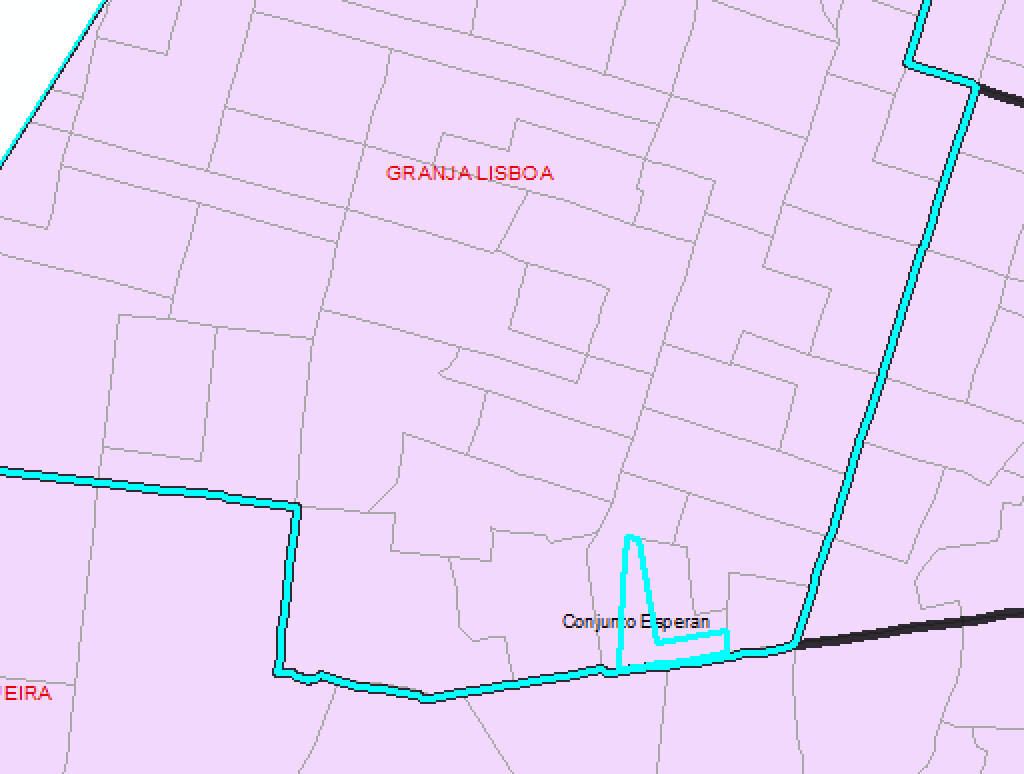

Conjunto Esperanca in Granja Lisboa

Old data

| ID | CD_GEOCODI | CD_GEOCODB | NM_BAIRRO | CD_GEOCODS | NM_SUBDIST | CD_GEOCODD | NM_DISTRIT | CD_GEOCODM | NM_MUNICIP | NM_MICRO | NM_MESO |
| --- | --- | --- | --- | --- | --- | --- | --- | --- | --- | --- | --- |
| 14463 | 230440070100132 | 230440070076 | Conjunto Esperanca | 23044007010 | CONJUNTO CEARA | 230440070 | MONDUBIM | 2304400 | FORTALEZA | FORTALEZA | METROPOLITANA DE FORTALEZA |

Corrected data

| ID | CD_GEOCODI | CD_GEOCODB_NEW | NM_BAIRRO_NEW | CD_GEOCODS_NEW | NM_SUBDIST_NEW | CD_GEOCODD_NEW | NM_DISTRIT_NEW | CD_GEOCODM_NEW | NM_MUNICIP_NEW | NM_MICRO_NEW | NM_MESO_NEW |
| --- | --- | --- | --- | --- | --- | --- | --- | --- | --- | --- | --- |
| 14463 | 230440070100132 | 230440070078 | Granja Lisboa | 23044007010 | CONJUNTO CEARA | 230440070 | MONDUBIM | 2304400 | FORTALEZA | FORTALEZA | METROPOLITANA DE FORTALEZA |

##### 9. Cajazeiras in Barroso

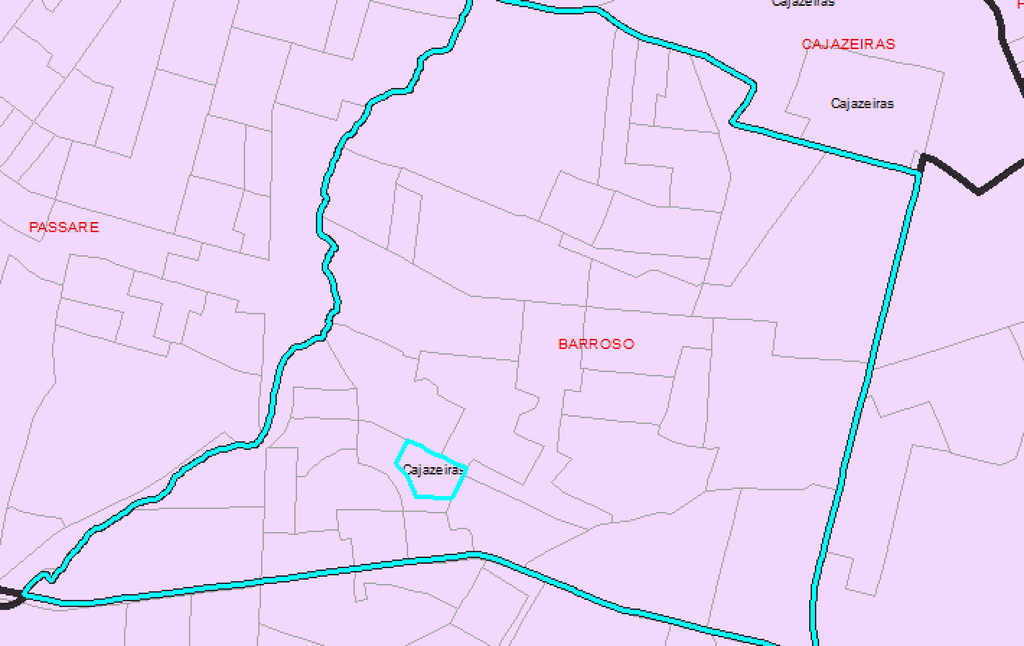

Cajazeiras in Barroso

Old data

| ID | CD_GEOCODI | CD_GEOCODB | NM_BAIRRO | CD_GEOCODS | NM_SUBDIST | CD_GEOCODD | NM_DISTRIT | CD_GEOCODM | NM_MUNICIP | NM_MICRO | NM_MESO |
| --- | --- | --- | --- | --- | --- | --- | --- | --- | --- | --- | --- |
| 14339 | 230440065110487 | 230440065052 | Cajazeiras | 23044006511 | MESSEJANA | 230440065 | MESSEJANA | 2304400 | FORTALEZA | FORTALEZA | METROPOLITANA DE FORTALEZA |

Corrected data

| ID | CD_GEOCODI | CD_GEOCODB_NEW | NM_BAIRRO_NEW | CD_GEOCODS_NEW | NM_SUBDIST_NEW | CD_GEOCODD_NEW | NM_DISTRIT_NEW | CD_GEOCODM_NEW | NM_MUNICIP_NEW | NM_MICRO_NEW | NM_MESO_NEW |
| --- | --- | --- | --- | --- | --- | --- | --- | --- | --- | --- | --- |
| 14339 | 230440065110487 | 230440065051 | Barroso | 23044006511 | MESSEJANA | 230440065 | MESSEJANA | 2304400 | FORTALEZA | FORTALEZA | METROPOLITANA DE FORTALEZA |

##### 10. Conjunto Palmeiras in Jangurussu

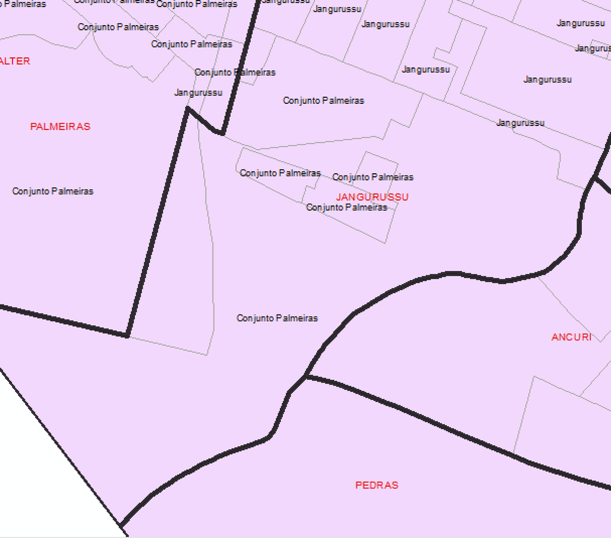

Conjunto Palmeiras in Jangurussu

Old data

| ID | CD_GEOCODI | CD_GEOCODB | NM_BAIRRO | CD_GEOCODS | NM_SUBDIST | CD_GEOCODD | NM_DISTRIT | CD_GEOCODM | NM_MUNICIP | NM_MICRO | NM_MESO |
| --- | --- | --- | --- | --- | --- | --- | --- | --- | --- | --- | --- |
| 14360 | 230440065110508 | 230440065118 | Conjunto Palmeiras | 23044006511 | MESSEJANA | 230440065 | MESSEJANA | 2304400 | FORTALEZA | FORTALEZA | METROPOLITANA DE FORTALEZA |
| 14359 | 230440065110507 | 230440065118 | Conjunto Palmeiras | 23044006511 | MESSEJANA | 230440065 | MESSEJANA | 2304400 | FORTALEZA | FORTALEZA | METROPOLITANA DE FORTALEZA |
| 14358 | 230440065110506 | 230440065118 | Conjunto Palmeiras | 23044006511 | MESSEJANA | 230440065 | MESSEJANA | 2304400 | FORTALEZA | FORTALEZA | METROPOLITANA DE FORTALEZA |
| 14357 | 230440065110505 | 230440065118 | Conjunto Palmeiras | 23044006511 | MESSEJANA | 230440065 | MESSEJANA | 2304400 | FORTALEZA | FORTALEZA | METROPOLITANA DE FORTALEZA |
| 14356 | 230440065110504 | 230440065118 | Conjunto Palmeiras | 23044006511 | MESSEJANA | 230440065 | MESSEJANA | 2304400 | FORTALEZA | FORTALEZA | METROPOLITANA DE FORTALEZA |

Corrected data

| ID | CD_GEOCODI | CD_GEOCODB_NEW | NM_BAIRRO_NEW | CD_GEOCODS_NEW | NM_SUBDIST_NEW | CD_GEOCODD_NEW | NM_DISTRIT_NEW | CD_GEOCODM_NEW | NM_MUNICIP_NEW | NM_MICRO_NEW | NM_MESO_NEW |
| --- | --- | --- | --- | --- | --- | --- | --- | --- | --- | --- | --- |
| 14360 | 230440065110508 | 230440065061 | Jangurussu | 23044006511 | MESSEJANA | 230440065 | MESSEJANA | 2304400 | FORTALEZA | FORTALEZA | METROPOLITANA DE FORTALEZA |
| 14359 | 230440065110507 | 230440065061 | Jangurussu | 23044006511 | MESSEJANA | 230440065 | MESSEJANA | 2304400 | FORTALEZA | FORTALEZA | METROPOLITANA DE FORTALEZA |
| 14358 | 230440065110506 | 230440065061 | Jangurussu | 23044006511 | MESSEJANA | 230440065 | MESSEJANA | 2304400 | FORTALEZA | FORTALEZA | METROPOLITANA DE FORTALEZA |
| 14357 | 230440065110505 | 230440065061 | Jangurussu | 23044006511 | MESSEJANA | 230440065 | MESSEJANA | 2304400 | FORTALEZA | FORTALEZA | METROPOLITANA DE FORTALEZA |
| 14356 | 230440065110504 | 230440065061 | Jangurussu | 23044006511 | MESSEJANA | 230440065 | MESSEJANA | 2304400 | FORTALEZA | FORTALEZA | METROPOLITANA DE FORTALEZA |

##### 11. Sao Bento in Paupina

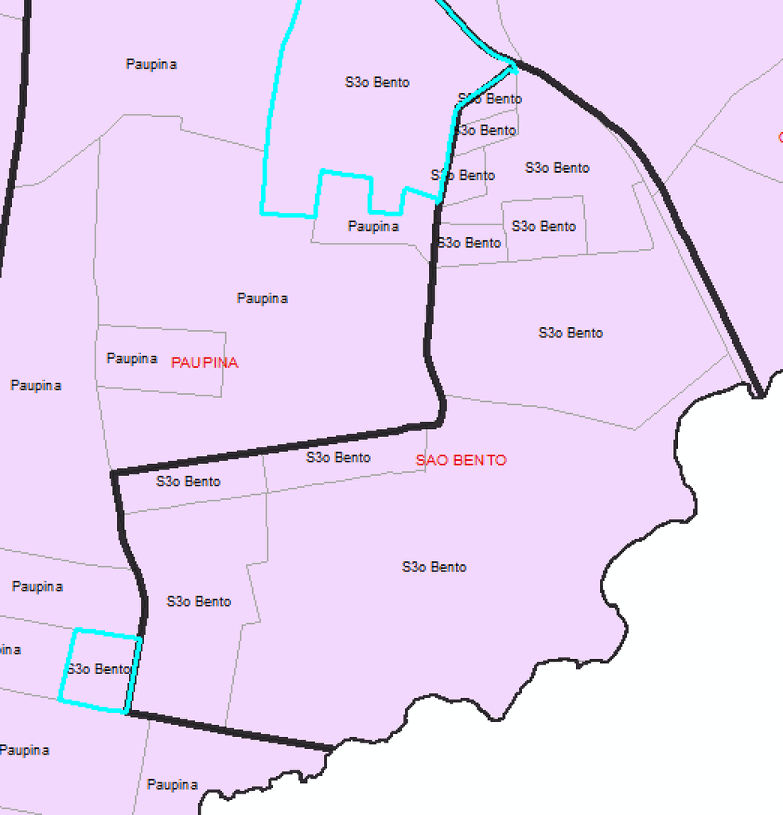

Sao Bento in Paupina

Old data

| ID | CD_GEOCODI | CD_GEOCODB | NM_BAIRRO | CD_GEOCODS | NM_SUBDIST | CD_GEOCODD | NM_DISTRIT | CD_GEOCODM | NM_MUNICIP | NM_MICRO | NM_MESO |
| --- | --- | --- | --- | --- | --- | --- | --- | --- | --- | --- | --- |
| 14140 | 230440065110173 | 230440065119 | Sao Bento | 23044006511 | MESSEJANA | 230440065 | MESSEJANA | 2304400 | FORTALEZA | FORTALEZA | METROPOLITANA DE FORTALEZA |
| 14348 | 230440065110496 | 230440065119 | Sao Bento | 23044006511 | MESSEJANA | 230440065 | MESSEJANA | 2304400 | FORTALEZA | FORTALEZA | METROPOLITANA DE FORTALEZA |

Corrected data

| ID | CD_GEOCODI | CD_GEOCODB_NEW | NM_BAIRRO_NEW | CD_GEOCODS_NEW | NM_SUBDIST_NEW | CD_GEOCODD_NEW | NM_DISTRIT_NEW | CD_GEOCODM_NEW | NM_MUNICIP_NEW | NM_MICRO_NEW | NM_MESO_NEW |
| --- | --- | --- | --- | --- | --- | --- | --- | --- | --- | --- | --- |
| 14140 | 230440065110173 | 230440065068 | Paupina | 23044006511 | MESSEJANA | 230440065 | MESSEJANA | 2304400 | FORTALEZA | FORTALEZA | METROPOLITANA DE FORTALEZA |
| 14348 | 230440065110496 | 230440065068 | Paupina | 23044006511 | MESSEJANA | 230440065 | MESSEJANA | 2304400 | FORTALEZA | FORTALEZA | METROPOLITANA DE FORTALEZA |

##### 12. Unnamed Eusebio bairro in Sabiaguaba

It seems like Fortaleza’s boundary in Sabiaguaba has increased since the census. Adding the highlighted census tract still does not cover all of the new boundaries, but the census tracts below go far beyond the existing boundaries. Moreover, looking at the basemap suggests that there are no significant populations in the edge of Sabiaguaba.

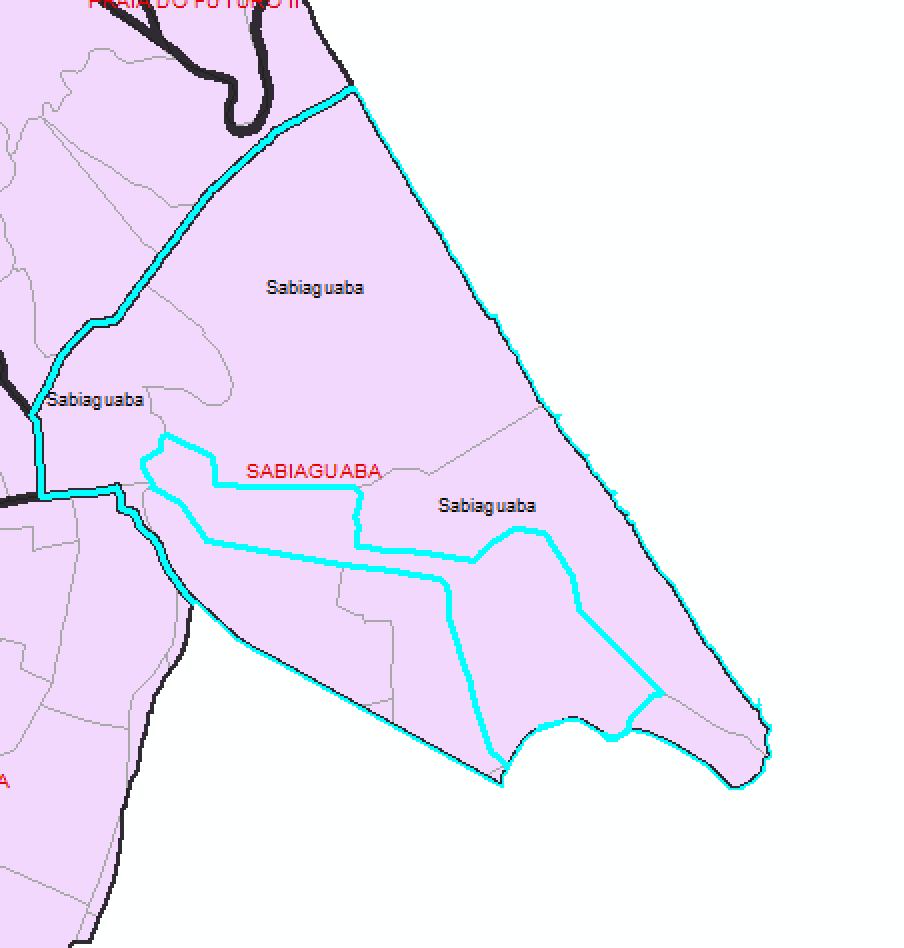

Unnamed Eusebio bairro in Sabiaguaba

Old data

| ID | CD_GEOCODI | CD_GEOCODB | NM_BAIRRO | CD_GEOCODS | NM_SUBDIST | CD_GEOCODD | NM_DISTRIT | CD_GEOCODM | NM_MUNICIP | NM_MICRO | NM_MESO |
| --- | --- | --- | --- | --- | --- | --- | --- | --- | --- | --- | --- |
| 12354 | 230428505000053 | NA | NA | 23042850500 | NA | 230428505 | EUSEBIO | 2304285 | EUSEBIO | FORTALEZA | METROPOLITANA DE FORTALEZA |

Corrected data

| ID | CD_GEOCODI | CD_GEOCODB_NEW | NM_BAIRRO_NEW | CD_GEOCODS_NEW | NM_SUBDIST_NEW | CD_GEOCODD_NEW | NM_DISTRIT_NEW | CD_GEOCODM_NEW | NM_MUNICIP_NEW | NM_MICRO_NEW | NM_MESO_NEW |
| --- | --- | --- | --- | --- | --- | --- | --- | --- | --- | --- | --- |
| 12354 | 230428505000053 | 230440065070 | Sabiaguaba | 23044006511 | MESSEJANA | 230440065 | MESSEJANA | 2304400 | FORTALEZA | FORTALEZA | METROPOLITANA DE FORTALEZA |

##### 13. Jangurussu in Conjunto Palmeiras

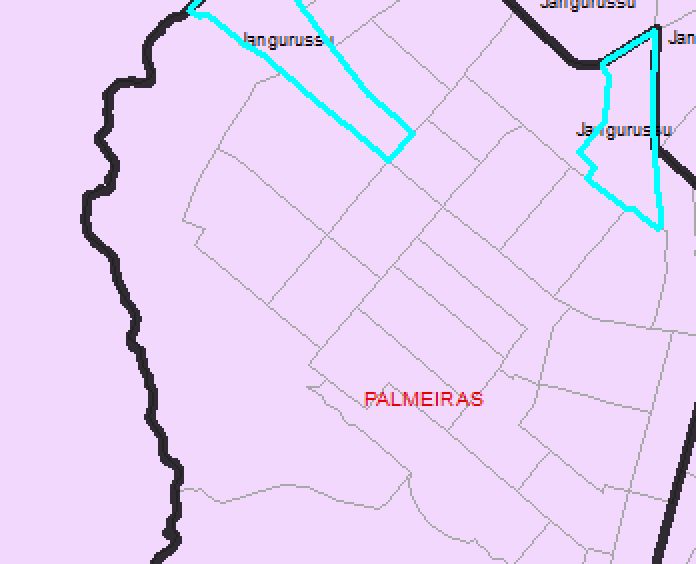

Jangurussu in Conjunto Palmeiras

Old data

| ID | CD_GEOCODI | CD_GEOCODB | NM_BAIRRO | CD_GEOCODS | NM_SUBDIST | CD_GEOCODD | NM_DISTRIT | CD_GEOCODM | NM_MUNICIP | NM_MICRO | NM_MESO |
| --- | --- | --- | --- | --- | --- | --- | --- | --- | --- | --- | --- |
| 14209 | 230440065110242 | 230440065061 | Jangurussu | 23044006511 | MESSEJANA | 230440065 | MESSEJANA | 2304400 | FORTALEZA | FORTALEZA | METROPOLITANA DE FORTALEZA |
| 14351 | 230440065110499 | 230440065061 | Jangurussu | 23044006511 | MESSEJANA | 230440065 | MESSEJANA | 2304400 | FORTALEZA | FORTALEZA | METROPOLITANA DE FORTALEZA |

Corrected data

| ID | CD_GEOCODI | CD_GEOCODB_NEW | NM_BAIRRO_NEW | CD_GEOCODS_NEW | NM_SUBDIST_NEW | CD_GEOCODD_NEW | NM_DISTRIT_NEW | CD_GEOCODM_NEW | NM_MUNICIP_NEW | NM_MICRO_NEW | NM_MESO_NEW |
| --- | --- | --- | --- | --- | --- | --- | --- | --- | --- | --- | --- |
| 14209 | 230440065110242 | 230440065118 | Conjunto Palmeiras | 23044006511 | MESSEJANA | 230440065 | MESSEJANA | 2304400 | FORTALEZA | FORTALEZA | METROPOLITANA DE FORTALEZA |
| 14351 | 230440065110499 | 230440065118 | Conjunto Palmeiras | 23044006511 | MESSEJANA | 230440065 | MESSEJANA | 2304400 | FORTALEZA | FORTALEZA | METROPOLITANA DE FORTALEZA |

##### 14. Quintino Cunha divides into Olavo Oliveira

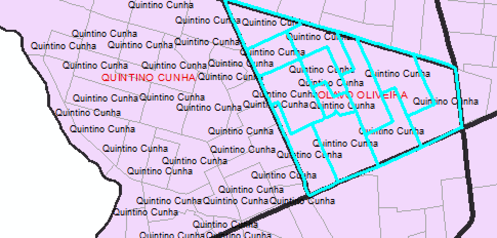

Quintino Cunha divides into Olavo Oliveira

Old data

| ID | CD_GEOCODI | CD_GEOCODB | NM_BAIRRO | CD_GEOCODS | NM_SUBDIST | CD_GEOCODD | NM_DISTRIT | CD_GEOCODM | NM_MUNICIP | NM_MICRO | NM_MESO |
| --- | --- | --- | --- | --- | --- | --- | --- | --- | --- | --- | --- |
| 13673 | 230440060060076 | 230440060048 | Quintino Cunha | 23044006006 | ANTONIO BEZERRA | 230440060 | ANTONIO BEZERRA | 2304400 | FORTALEZA | FORTALEZA | METROPOLITANA DE FORTALEZA |
| 13674 | 230440060060077 | 230440060048 | Quintino Cunha | 23044006006 | ANTONIO BEZERRA | 230440060 | ANTONIO BEZERRA | 2304400 | FORTALEZA | FORTALEZA | METROPOLITANA DE FORTALEZA |
| 13675 | 230440060060078 | 230440060048 | Quintino Cunha | 23044006006 | ANTONIO BEZERRA | 230440060 | ANTONIO BEZERRA | 2304400 | FORTALEZA | FORTALEZA | METROPOLITANA DE FORTALEZA |
| 13676 | 230440060060079 | 230440060048 | Quintino Cunha | 23044006006 | ANTONIO BEZERRA | 230440060 | ANTONIO BEZERRA | 2304400 | FORTALEZA | FORTALEZA | METROPOLITANA DE FORTALEZA |
| 13677 | 230440060060080 | 230440060048 | Quintino Cunha | 23044006006 | ANTONIO BEZERRA | 230440060 | ANTONIO BEZERRA | 2304400 | FORTALEZA | FORTALEZA | METROPOLITANA DE FORTALEZA |
| 13678 | 230440060060081 | 230440060048 | Quintino Cunha | 23044006006 | ANTONIO BEZERRA | 230440060 | ANTONIO BEZERRA | 2304400 | FORTALEZA | FORTALEZA | METROPOLITANA DE FORTALEZA |
| 13679 | 230440060060082 | 230440060048 | Quintino Cunha | 23044006006 | ANTONIO BEZERRA | 230440060 | ANTONIO BEZERRA | 2304400 | FORTALEZA | FORTALEZA | METROPOLITANA DE FORTALEZA |
| 13680 | 230440060060083 | 230440060048 | Quintino Cunha | 23044006006 | ANTONIO BEZERRA | 230440060 | ANTONIO BEZERRA | 2304400 | FORTALEZA | FORTALEZA | METROPOLITANA DE FORTALEZA |
| 13681 | 230440060060084 | 230440060048 | Quintino Cunha | 23044006006 | ANTONIO BEZERRA | 230440060 | ANTONIO BEZERRA | 2304400 | FORTALEZA | FORTALEZA | METROPOLITANA DE FORTALEZA |
| 13764 | 230440060060213 | 230440060048 | Quintino Cunha | 23044006006 | ANTONIO BEZERRA | 230440060 | ANTONIO BEZERRA | 2304400 | FORTALEZA | FORTALEZA | METROPOLITANA DE FORTALEZA |
| 13765 | 230440060060214 | 230440060048 | Quintino Cunha | 23044006006 | ANTONIO BEZERRA | 230440060 | ANTONIO BEZERRA | 2304400 | FORTALEZA | FORTALEZA | METROPOLITANA DE FORTALEZA |
| 13766 | 230440060060215 | 230440060048 | Quintino Cunha | 23044006006 | ANTONIO BEZERRA | 230440060 | ANTONIO BEZERRA | 2304400 | FORTALEZA | FORTALEZA | METROPOLITANA DE FORTALEZA |

Corrected data

| ID | CD_GEOCODI | CD_GEOCODB_NEW | NM_BAIRRO_NEW | CD_GEOCODS_NEW | NM_SUBDIST_NEW | CD_GEOCODD_NEW | NM_DISTRIT_NEW | CD_GEOCODM_NEW | NM_MUNICIP_NEW | NM_MICRO_NEW | NM_MESO_NEW |
| --- | --- | --- | --- | --- | --- | --- | --- | --- | --- | --- | --- |
| 13673 | 230440060060076 | 2304400600480 | Olavo Oliveira | 23044006006 | ANTONIO BEZERRA | 230440060 | ANTONIO BEZERRA | 2304400 | FORTALEZA | FORTALEZA | METROPOLITANA DE FORTALEZA |
| 13674 | 230440060060077 | 2304400600480 | Olavo Oliveira | 23044006006 | ANTONIO BEZERRA | 230440060 | ANTONIO BEZERRA | 2304400 | FORTALEZA | FORTALEZA | METROPOLITANA DE FORTALEZA |
| 13675 | 230440060060078 | 2304400600480 | Olavo Oliveira | 23044006006 | ANTONIO BEZERRA | 230440060 | ANTONIO BEZERRA | 2304400 | FORTALEZA | FORTALEZA | METROPOLITANA DE FORTALEZA |
| 13676 | 230440060060079 | 2304400600480 | Olavo Oliveira | 23044006006 | ANTONIO BEZERRA | 230440060 | ANTONIO BEZERRA | 2304400 | FORTALEZA | FORTALEZA | METROPOLITANA DE FORTALEZA |
| 13677 | 230440060060080 | 2304400600480 | Olavo Oliveira | 23044006006 | ANTONIO BEZERRA | 230440060 | ANTONIO BEZERRA | 2304400 | FORTALEZA | FORTALEZA | METROPOLITANA DE FORTALEZA |
| 13678 | 230440060060081 | 2304400600480 | Olavo Oliveira | 23044006006 | ANTONIO BEZERRA | 230440060 | ANTONIO BEZERRA | 2304400 | FORTALEZA | FORTALEZA | METROPOLITANA DE FORTALEZA |
| 13679 | 230440060060082 | 2304400600480 | Olavo Oliveira | 23044006006 | ANTONIO BEZERRA | 230440060 | ANTONIO BEZERRA | 2304400 | FORTALEZA | FORTALEZA | METROPOLITANA DE FORTALEZA |
| 13680 | 230440060060083 | 2304400600480 | Olavo Oliveira | 23044006006 | ANTONIO BEZERRA | 230440060 | ANTONIO BEZERRA | 2304400 | FORTALEZA | FORTALEZA | METROPOLITANA DE FORTALEZA |
| 13681 | 230440060060084 | 2304400600480 | Olavo Oliveira | 23044006006 | ANTONIO BEZERRA | 230440060 | ANTONIO BEZERRA | 2304400 | FORTALEZA | FORTALEZA | METROPOLITANA DE FORTALEZA |
| 13764 | 230440060060213 | 2304400600480 | Olavo Oliveira | 23044006006 | ANTONIO BEZERRA | 230440060 | ANTONIO BEZERRA | 2304400 | FORTALEZA | FORTALEZA | METROPOLITANA DE FORTALEZA |
| 13765 | 230440060060214 | 2304400600480 | Olavo Oliveira | 23044006006 | ANTONIO BEZERRA | 230440060 | ANTONIO BEZERRA | 2304400 | FORTALEZA | FORTALEZA | METROPOLITANA DE FORTALEZA |
| 13766 | 230440060060215 | 2304400600480 | Olavo Oliveira | 23044006006 | ANTONIO BEZERRA | 230440060 | ANTONIO BEZERRA | 2304400 | FORTALEZA | FORTALEZA | METROPOLITANA DE FORTALEZA |

##### 15. Dias Macedo, Castelao and Mata Galinha become Boa Vista

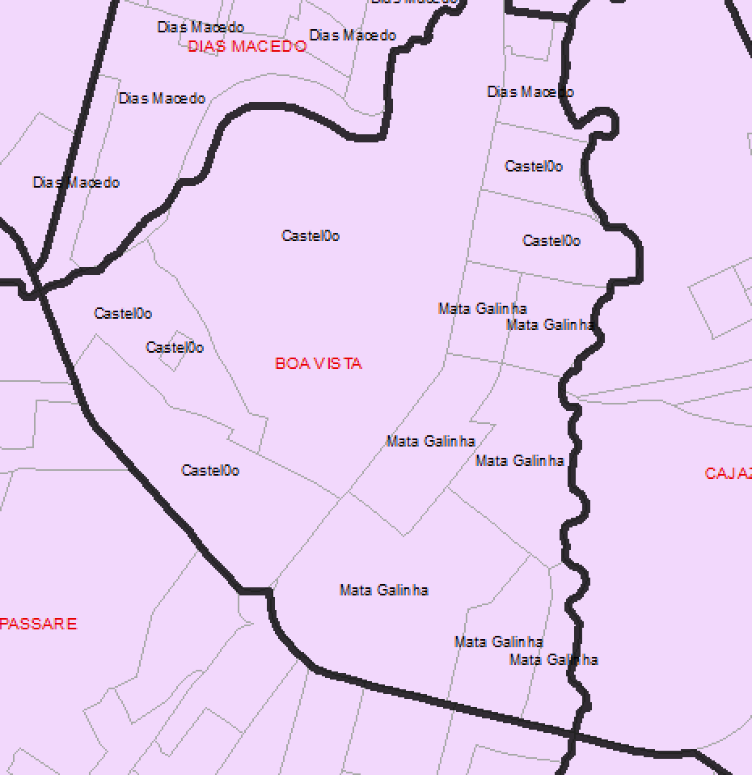

Dias Macedo, Castelao and Mata Galinha become Boa Vista

Old data

| ID | CD_GEOCODI | CD_GEOCODB | NM_BAIRRO | CD_GEOCODS | NM_SUBDIST | CD_GEOCODD | NM_DISTRIT | CD_GEOCODM | NM_MUNICIP | NM_MICRO | NM_MESO |
| --- | --- | --- | --- | --- | --- | --- | --- | --- | --- | --- | --- |
| 15318 | 230440075130248 | 230440075098 | Dias Macedo | 23044007513 | PARAPARANGABA | 230440075 | PARANGABA | 2304400 | FORTALEZA | FORTALEZA | METROPOLITANA DE FORTALEZA |
| 15324 | 230440075130254 | 230440075095 | Castelao | 23044007514 | PARAPARANGABA | 230440076 | PARANGABA | 2304401 | FORTALEZA | FORTALEZA | METROPOLITANA DE FORTALEZA |
| 15325 | 230440075130255 | 230440075095 | Castelao | 23044007515 | PARAPARANGABA | 230440077 | PARANGABA | 2304402 | FORTALEZA | FORTALEZA | METROPOLITANA DE FORTALEZA |
| 15326 | 230440075130256 | 230440075095 | Castelao | 23044007516 | PARAPARANGABA | 230440078 | PARANGABA | 2304403 | FORTALEZA | FORTALEZA | METROPOLITANA DE FORTALEZA |
| 15327 | 230440075130257 | 230440075095 | Castelao | 23044007517 | PARAPARANGABA | 230440079 | PARANGABA | 2304404 | FORTALEZA | FORTALEZA | METROPOLITANA DE FORTALEZA |
| 15328 | 230440075130258 | 230440075102 | Mata Galinha | 23044007518 | PARAPARANGABA | 230440080 | PARANGABA | 2304405 | FORTALEZA | FORTALEZA | METROPOLITANA DE FORTALEZA |
| 15329 | 230440075130259 | 230440075102 | Mata Galinha | 23044007519 | PARAPARANGABA | 230440081 | PARANGABA | 2304406 | FORTALEZA | FORTALEZA | METROPOLITANA DE FORTALEZA |
| 15330 | 230440075130260 | 230440075102 | Mata Galinha | 23044007520 | PARAPARANGABA | 230440082 | PARANGABA | 2304407 | FORTALEZA | FORTALEZA | METROPOLITANA DE FORTALEZA |
| 15331 | 230440075130261 | 230440075102 | Mata Galinha | 23044007521 | PARAPARANGABA | 230440083 | PARANGABA | 2304408 | FORTALEZA | FORTALEZA | METROPOLITANA DE FORTALEZA |
| 15448 | 230440075130378 | 230440075095 | Castelao | 23044007522 | PARAPARANGABA | 230440084 | PARANGABA | 2304409 | FORTALEZA | FORTALEZA | METROPOLITANA DE FORTALEZA |
| 15449 | 230440075130379 | 230440075095 | Castelao | 23044007523 | PARAPARANGABA | 230440085 | PARANGABA | 2304410 | FORTALEZA | FORTALEZA | METROPOLITANA DE FORTALEZA |
| 15450 | 230440075130380 | 230440075102 | Mata Galinha | 23044007524 | PARAPARANGABA | 230440086 | PARANGABA | 2304411 | FORTALEZA | FORTALEZA | METROPOLITANA DE FORTALEZA |
| 15451 | 230440075130381 | 230440075102 | Mata Galinha | 23044007525 | PARAPARANGABA | 230440087 | PARANGABA | 2304412 | FORTALEZA | FORTALEZA | METROPOLITANA DE FORTALEZA |
| 15452 | 230440075130382 | 230440075102 | Mata Galinha | 23044007526 | PARAPARANGABA | 230440088 | PARANGABA | 2304413 | FORTALEZA | FORTALEZA | METROPOLITANA DE FORTALEZA |

Corrected data

| ID | CD_GEOCODI | CD_GEOCODB_NEW | NM_BAIRRO_NEW | CD_GEOCODS_NEW | NM_SUBDIST_NEW | CD_GEOCODD_NEW | NM_DISTRIT_NEW | CD_GEOCODM_NEW | NM_MUNICIP_NEW | NM_MICRO_NEW | NM_MESO_NEW |
| --- | --- | --- | --- | --- | --- | --- | --- | --- | --- | --- | --- |
| 15318 | 230440075130248 | 2304400750980 | Boa Vista | 23044007513 | PARANGABA | 230440075 | PARANGABA | 2304400 | FORTALEZA | FORTALEZA | METROPOLITANA DE FORTALEZA |
| 15324 | 230440075130254 | 2304400750980 | Boa Vista | 23044007514 | PARANGABA | 230440076 | PARANGABA | 2304401 | FORTALEZA | FORTALEZA | METROPOLITANA DE FORTALEZA |
| 15325 | 230440075130255 | 2304400750980 | Boa Vista | 23044007515 | PARANGABA | 230440077 | PARANGABA | 2304402 | FORTALEZA | FORTALEZA | METROPOLITANA DE FORTALEZA |
| 15326 | 230440075130256 | 2304400750980 | Boa Vista | 23044007516 | PARANGABA | 230440078 | PARANGABA | 2304403 | FORTALEZA | FORTALEZA | METROPOLITANA DE FORTALEZA |
| 15327 | 230440075130257 | 2304400750980 | Boa Vista | 23044007517 | PARANGABA | 230440079 | PARANGABA | 2304404 | FORTALEZA | FORTALEZA | METROPOLITANA DE FORTALEZA |
| 15328 | 230440075130258 | 2304400750980 | Boa Vista | 23044007518 | PARANGABA | 230440080 | PARANGABA | 2304405 | FORTALEZA | FORTALEZA | METROPOLITANA DE FORTALEZA |
| 15329 | 230440075130259 | 2304400750980 | Boa Vista | 23044007519 | PARANGABA | 230440081 | PARANGABA | 2304406 | FORTALEZA | FORTALEZA | METROPOLITANA DE FORTALEZA |
| 15330 | 230440075130260 | 2304400750980 | Boa Vista | 23044007520 | PARANGABA | 230440082 | PARANGABA | 2304407 | FORTALEZA | FORTALEZA | METROPOLITANA DE FORTALEZA |
| 15331 | 230440075130261 | 2304400750980 | Boa Vista | 23044007521 | PARANGABA | 230440083 | PARANGABA | 2304408 | FORTALEZA | FORTALEZA | METROPOLITANA DE FORTALEZA |
| 15448 | 230440075130378 | 2304400750980 | Boa Vista | 23044007522 | PARANGABA | 230440084 | PARANGABA | 2304409 | FORTALEZA | FORTALEZA | METROPOLITANA DE FORTALEZA |
| 15449 | 230440075130379 | 2304400750980 | Boa Vista | 23044007523 | PARANGABA | 230440085 | PARANGABA | 2304410 | FORTALEZA | FORTALEZA | METROPOLITANA DE FORTALEZA |
| 15450 | 230440075130380 | 2304400750980 | Boa Vista | 23044007524 | PARANGABA | 230440086 | PARANGABA | 2304411 | FORTALEZA | FORTALEZA | METROPOLITANA DE FORTALEZA |
| 15451 | 230440075130381 | 2304400750980 | Boa Vista | 23044007525 | PARANGABA | 230440087 | PARANGABA | 2304412 | FORTALEZA | FORTALEZA | METROPOLITANA DE FORTALEZA |
| 15452 | 230440075130382 | 2304400750980 | Boa Vista | 23044007526 | PARANGABA | 230440088 | PARANGABA | 2304413 | FORTALEZA | FORTALEZA | METROPOLITANA DE FORTALEZA |

##### 16. Ancuri divides into Parque Santa Maria

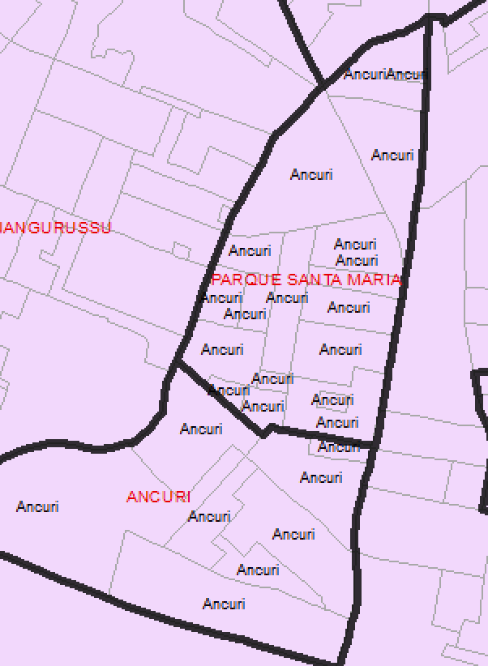

Ancuri divides into Parque Santa Maria

Old data

| ID | CD_GEOCODI | CD_GEOCODB | NM_BAIRRO | CD_GEOCODS | NM_SUBDIST | CD_GEOCODD | NM_DISTRIT | CD_GEOCODM | NM_MUNICIP | NM_MICRO | NM_MESO |
| --- | --- | --- | --- | --- | --- | --- | --- | --- | --- | --- | --- |
| 14155 | 230440065110188 | 230440065050 | Ancuri | 23044006511 | MESSEJANA | 230440065 | MESSEJANA | 2304400 | FORTALEZA | FORTALEZA | METROPOLITANA DE FORTALEZA |
| 14156 | 230440065110189 | 230440065050 | Ancuri | 23044006511 | MESSEJANA | 230440065 | MESSEJANA | 2304400 | FORTALEZA | FORTALEZA | METROPOLITANA DE FORTALEZA |
| 14157 | 230440065110190 | 230440065050 | Ancuri | 23044006511 | MESSEJANA | 230440065 | MESSEJANA | 2304400 | FORTALEZA | FORTALEZA | METROPOLITANA DE FORTALEZA |
| 14158 | 230440065110191 | 230440065050 | Ancuri | 23044006511 | MESSEJANA | 230440065 | MESSEJANA | 2304400 | FORTALEZA | FORTALEZA | METROPOLITANA DE FORTALEZA |
| 14159 | 230440065110192 | 230440065050 | Ancuri | 23044006511 | MESSEJANA | 230440065 | MESSEJANA | 2304400 | FORTALEZA | FORTALEZA | METROPOLITANA DE FORTALEZA |
| 14160 | 230440065110193 | 230440065050 | Ancuri | 23044006511 | MESSEJANA | 230440065 | MESSEJANA | 2304400 | FORTALEZA | FORTALEZA | METROPOLITANA DE FORTALEZA |
| 14161 | 230440065110194 | 230440065050 | Ancuri | 23044006511 | MESSEJANA | 230440065 | MESSEJANA | 2304400 | FORTALEZA | FORTALEZA | METROPOLITANA DE FORTALEZA |
| 14162 | 230440065110195 | 230440065050 | Ancuri | 23044006511 | MESSEJANA | 230440065 | MESSEJANA | 2304400 | FORTALEZA | FORTALEZA | METROPOLITANA DE FORTALEZA |
| 14163 | 230440065110196 | 230440065050 | Ancuri | 23044006511 | MESSEJANA | 230440065 | MESSEJANA | 2304400 | FORTALEZA | FORTALEZA | METROPOLITANA DE FORTALEZA |
| 14164 | 230440065110197 | 230440065050 | Ancuri | 23044006511 | MESSEJANA | 230440065 | MESSEJANA | 2304400 | FORTALEZA | FORTALEZA | METROPOLITANA DE FORTALEZA |
| 14165 | 230440065110198 | 230440065050 | Ancuri | 23044006511 | MESSEJANA | 230440065 | MESSEJANA | 2304400 | FORTALEZA | FORTALEZA | METROPOLITANA DE FORTALEZA |
| 14166 | 230440065110199 | 230440065050 | Ancuri | 23044006511 | MESSEJANA | 230440065 | MESSEJANA | 2304400 | FORTALEZA | FORTALEZA | METROPOLITANA DE FORTALEZA |
| 14296 | 230440065110444 | 230440065050 | Ancuri | 23044006511 | MESSEJANA | 230440065 | MESSEJANA | 2304400 | FORTALEZA | FORTALEZA | METROPOLITANA DE FORTALEZA |
| 14297 | 230440065110445 | 230440065050 | Ancuri | 23044006511 | MESSEJANA | 230440065 | MESSEJANA | 2304400 | FORTALEZA | FORTALEZA | METROPOLITANA DE FORTALEZA |
| 14298 | 230440065110446 | 230440065050 | Ancuri | 23044006511 | MESSEJANA | 230440065 | MESSEJANA | 2304400 | FORTALEZA | FORTALEZA | METROPOLITANA DE FORTALEZA |
| 14299 | 230440065110447 | 230440065050 | Ancuri | 23044006511 | MESSEJANA | 230440065 | MESSEJANA | 2304400 | FORTALEZA | FORTALEZA | METROPOLITANA DE FORTALEZA |
| 14300 | 230440065110448 | 230440065050 | Ancuri | 23044006511 | MESSEJANA | 230440065 | MESSEJANA | 2304400 | FORTALEZA | FORTALEZA | METROPOLITANA DE FORTALEZA |
| 14301 | 230440065110449 | 230440065050 | Ancuri | 23044006511 | MESSEJANA | 230440065 | MESSEJANA | 2304400 | FORTALEZA | FORTALEZA | METROPOLITANA DE FORTALEZA |

Corrected data

| ID | CD_GEOCODI | CD_GEOCODB_NEW | NM_BAIRRO_NEW | CD_GEOCODS_NEW | NM_SUBDIST_NEW | CD_GEOCODD_NEW | NM_DISTRIT_NEW | CD_GEOCODM_NEW | NM_MUNICIP_NEW | NM_MICRO_NEW | NM_MESO_NEW |
| --- | --- | --- | --- | --- | --- | --- | --- | --- | --- | --- | --- |
| 14155 | 230440065110188 | 2304400650500 | Parque Santa Maria | 23044006511 | MESSEJANA | 230440065 | MESSEJANA | 2304400 | FORTALEZA | FORTALEZA | METROPOLITANA DE FORTALEZA |
| 14156 | 230440065110189 | 2304400650500 | Parque Santa Maria | 23044006511 | MESSEJANA | 230440065 | MESSEJANA | 2304400 | FORTALEZA | FORTALEZA | METROPOLITANA DE FORTALEZA |
| 14157 | 230440065110190 | 2304400650500 | Parque Santa Maria | 23044006511 | MESSEJANA | 230440065 | MESSEJANA | 2304400 | FORTALEZA | FORTALEZA | METROPOLITANA DE FORTALEZA |
| 14158 | 230440065110191 | 2304400650500 | Parque Santa Maria | 23044006511 | MESSEJANA | 230440065 | MESSEJANA | 2304400 | FORTALEZA | FORTALEZA | METROPOLITANA DE FORTALEZA |
| 14159 | 230440065110192 | 2304400650500 | Parque Santa Maria | 23044006511 | MESSEJANA | 230440065 | MESSEJANA | 2304400 | FORTALEZA | FORTALEZA | METROPOLITANA DE FORTALEZA |
| 14160 | 230440065110193 | 2304400650500 | Parque Santa Maria | 23044006511 | MESSEJANA | 230440065 | MESSEJANA | 2304400 | FORTALEZA | FORTALEZA | METROPOLITANA DE FORTALEZA |
| 14161 | 230440065110194 | 2304400650500 | Parque Santa Maria | 23044006511 | MESSEJANA | 230440065 | MESSEJANA | 2304400 | FORTALEZA | FORTALEZA | METROPOLITANA DE FORTALEZA |
| 14162 | 230440065110195 | 2304400650500 | Parque Santa Maria | 23044006511 | MESSEJANA | 230440065 | MESSEJANA | 2304400 | FORTALEZA | FORTALEZA | METROPOLITANA DE FORTALEZA |
| 14163 | 230440065110196 | 2304400650500 | Parque Santa Maria | 23044006511 | MESSEJANA | 230440065 | MESSEJANA | 2304400 | FORTALEZA | FORTALEZA | METROPOLITANA DE FORTALEZA |
| 14164 | 230440065110197 | 2304400650500 | Parque Santa Maria | 23044006511 | MESSEJANA | 230440065 | MESSEJANA | 2304400 | FORTALEZA | FORTALEZA | METROPOLITANA DE FORTALEZA |
| 14165 | 230440065110198 | 2304400650500 | Parque Santa Maria | 23044006511 | MESSEJANA | 230440065 | MESSEJANA | 2304400 | FORTALEZA | FORTALEZA | METROPOLITANA DE FORTALEZA |
| 14166 | 230440065110199 | 2304400650500 | Parque Santa Maria | 23044006511 | MESSEJANA | 230440065 | MESSEJANA | 2304400 | FORTALEZA | FORTALEZA | METROPOLITANA DE FORTALEZA |
| 14296 | 230440065110444 | 2304400650500 | Parque Santa Maria | 23044006511 | MESSEJANA | 230440065 | MESSEJANA | 2304400 | FORTALEZA | FORTALEZA | METROPOLITANA DE FORTALEZA |
| 14297 | 230440065110445 | 2304400650500 | Parque Santa Maria | 23044006511 | MESSEJANA | 230440065 | MESSEJANA | 2304400 | FORTALEZA | FORTALEZA | METROPOLITANA DE FORTALEZA |
| 14298 | 230440065110446 | 2304400650500 | Parque Santa Maria | 23044006511 | MESSEJANA | 230440065 | MESSEJANA | 2304400 | FORTALEZA | FORTALEZA | METROPOLITANA DE FORTALEZA |
| 14299 | 230440065110447 | 2304400650500 | Parque Santa Maria | 23044006511 | MESSEJANA | 230440065 | MESSEJANA | 2304400 | FORTALEZA | FORTALEZA | METROPOLITANA DE FORTALEZA |
| 14300 | 230440065110448 | 2304400650500 | Parque Santa Maria | 23044006511 | MESSEJANA | 230440065 | MESSEJANA | 2304400 | FORTALEZA | FORTALEZA | METROPOLITANA DE FORTALEZA |
| 14301 | 230440065110449 | 2304400650500 | Parque Santa Maria | 23044006511 | MESSEJANA | 230440065 | MESSEJANA | 2304400 | FORTALEZA | FORTALEZA | METROPOLITANA DE FORTALEZA |

#### Comparison of population totals after new aggregation

| Bairro | Old_pop | New_pop |
| --- | --- | --- |
| Aerolndia | 11360 | 11360 |
| Aeroporto (Base Area) | 8618 | 8618 |
| Alagadio | 14505 | 14505 |
| Aldeota | 42361 | 42361 |
| Alto da Balana | 12814 | 12814 |
| çlvaro Weyne | 23690 | 24047 |
| Amadeo Furtado | 11703 | 11703 |
| Ancuri | 20070 | 6728 |
| Antnio Bezerra | 25846 | 25846 |
| Arraial Moura Brasil | 3765 | 3765 |
| Autran Nunes | 21208 | 21208 |
| Barra do Cear | 72423 | 72423 |
| Barroso | 29847 | 30551 |
| Bela Vista | 16754 | 16754 |
| Benfica | 8970 | 13248 |
| Boa Vista (new) | NA | 13062 |
| Bom Futuro | 6405 | 6405 |
| Bom Jardim | 37758 | 37758 |
| Bonsucesso | 41198 | 41198 |
| Cais do Porto | 22382 | 22382 |
| Cajazeiras | 14478 | 13774 |
| Cambeba | 7625 | 7625 |
| Canindezinho | 41202 | 41202 |
| Carlito Pamplona | 29076 | 29076 |
| Castelo (old) | 5974 | NA |
| Centro | 28538 | 28538 |
| Cidade dos Funcionrios | 18256 | 18256 |
| Cidade 2000 | 8272 | 8272 |
| Coau | 7188 | 7188 |
| Coco | 20492 | 20492 |

[output cut: 92 more lines]

#### Overall Correction Table

This table was used to correct the census tracts Bairro assignments in Fortaleza.

| ID | CD_GEOCODI | TIPO | CD_GEOCODB | NM_BAIRRO | CD_GEOCODS | NM_SUBDIST | CD_GEOCODD | NM_DISTRIT | CD_GEOCODM | NM_MUNICIP | NM_MICRO | NM_MESO | TIPO_NEW | CD_GEOCODB_NEW | NM_BAIRRO_NEW | CD_GEOCODS_NEW | NM_SUBDIST_NEW | CD_GEOCODD_NEW | NM_DISTRIT_NEW | CD_GEOCODM_NEW | NM_MUNICIP_NEW | NM_MICRO_NEW | NM_MESO_NEW |
| --- | --- | --- | --- | --- | --- | --- | --- | --- | --- | --- | --- | --- | --- | --- | --- | --- | --- | --- | --- | --- | --- | --- | --- |
| 12868 | 230440005070949 | URBAN | 230440005038 | Vila Ellery | 23044000507 | BARRA DO CEARA | 230440005 | FORTALEZA | 2304400 | FORTALEZA | FORTALEZA | METROPOLITANA DE FORTALEZA | URBAN | 230440005003 | Alvaro Weyne | 23044000507 | BARRA DO CEARA | 230440005 | FORTALEZA | 2304400 | FORTALEZA | FORTALEZA | METROPOLITANA DE FORTALEZA |
| 13531 | 230440005121095 | URBAN | 230440005036 | Varjota | 23044000512 | MUCURIPE | 230440005 | FORTALEZA | 2304400 | FORTALEZA | FORTALEZA | METROPOLITANA DE FORTALEZA | URBAN | 230440005027 | Papicu | 23044000512 | MUCURIPE | 230440005 | FORTALEZA | 2304400 | FORTALEZA | FORTALEZA | METROPOLITANA DE FORTALEZA |
| 13359 | 230440005120414 | URBAN | 230440005115 | De Lourdes | 23044000512 | MUCURIPE | 230440005 | FORTALEZA | 2304400 | FORTALEZA | FORTALEZA | METROPOLITANA DE FORTALEZA | URBAN | 230440005027 | Papicu | 23044000512 | MUCURIPE | 230440005 | FORTALEZA | 2304400 | FORTALEZA | FORTALEZA | METROPOLITANA DE FORTALEZA |
| 13349 | 230440005120404 | URBAN | 230440005115 | De Lourdes | 23044000512 | MUCURIPE | 230440005 | FORTALEZA | 2304400 | FORTALEZA | FORTALEZA | METROPOLITANA DE FORTALEZA | URBAN | 230440005027 | Papicu | 23044000512 | MUCURIPE | 230440005 | FORTALEZA | 2304400 | FORTALEZA | FORTALEZA | METROPOLITANA DE FORTALEZA |
| 13348 | 230440005120403 | URBAN | 230440005115 | De Lourdes | 23044000512 | MUCURIPE | 230440005 | FORTALEZA | 2304400 | FORTALEZA | FORTALEZA | METROPOLITANA DE FORTALEZA | URBAN | 230440005027 | Papicu | 23044000512 | MUCURIPE | 230440005 | FORTALEZA | 2304400 | FORTALEZA | FORTALEZA | METROPOLITANA DE FORTALEZA |
| 13530 | 230440005121094 | URBAN | 230440005036 | Varjota | 23044000512 | MUCURIPE | 230440005 | FORTALEZA | 2304400 | FORTALEZA | FORTALEZA | METROPOLITANA DE FORTALEZA | URBAN | 230440005024 | Meireles | 23044000512 | MUCURIPE | 230440005 | FORTALEZA | 2304400 | FORTALEZA | FORTALEZA | METROPOLITANA DE FORTALEZA |
| 13255 | 230440005081034 | URBAN | 230440005030 | Parreo | 23044000508 | CENTRO | 230440005 | FORTALEZA | 2304400 | FORTALEZA | FORTALEZA | METROPOLITANA DE FORTALEZA | URBAN | 230440005035 | Sao Joao do Taupe | 23044000508 | CENTRO | 230440005 | FORTALEZA | 2304400 | FORTALEZA | FORTALEZA | METROPOLITANA DE FORTALEZA |
| 13554 | 230440005121118 | URBAN | 230440005114 | Praia do Futuro II | 23044000512 | MUCURIPE | 230440005 | FORTALEZA | 2304400 | FORTALEZA | FORTALEZA | METROPOLITANA DE FORTALEZA | URBAN | 230440005112 | Manuel Dias Branco | 23044000512 | MUCURIPE | 230440005 | FORTALEZA | 2304400 | FORTALEZA | FORTALEZA | METROPOLITANA DE FORTALEZA |
| 13595 | 230440005121159 | URBAN | 230440005114 | Praia do Futuro II | 23044000512 | MUCURIPE | 230440005 | FORTALEZA | 2304400 | FORTALEZA | FORTALEZA | METROPOLITANA DE FORTALEZA | URBAN | 230440005112 | Manuel Dias Branco | 23044000512 | MUCURIPE | 230440005 | FORTALEZA | 2304400 | FORTALEZA | FORTALEZA | METROPOLITANA DE FORTALEZA |
| 13596 | 230440005121160 | URBAN | 230440005114 | Praia do Futuro II | 23044000512 | MUCURIPE | 230440005 | FORTALEZA | 2304400 | FORTALEZA | FORTALEZA | METROPOLITANA DE FORTALEZA | URBAN | 230440005112 | Manuel Dias Branco | 23044000512 | MUCURIPE | 230440005 | FORTALEZA | 2304400 | FORTALEZA | FORTALEZA | METROPOLITANA DE FORTALEZA |
| 13589 | 230440005121153 | URBAN | 230440005113 | Praia do Futuro I | 23044000512 | MUCURIPE | 230440005 | FORTALEZA | 2304400 | FORTALEZA | FORTALEZA | METROPOLITANA DE FORTALEZA | URBAN | 230440005114 | Praia do Futuro II | 23044000512 | MUCURIPE | 230440005 | FORTALEZA | 2304400 | FORTALEZA | FORTALEZA | METROPOLITANA DE FORTALEZA |
| 13591 | 230440005121155 | URBAN | 230440005113 | Praia do Futuro I | 23044000512 | MUCURIPE | 230440005 | FORTALEZA | 2304400 | FORTALEZA | FORTALEZA | METROPOLITANA DE FORTALEZA | URBAN | 230440005114 | Praia do Futuro II | 23044000512 | MUCURIPE | 230440005 | FORTALEZA | 2304400 | FORTALEZA | FORTALEZA | METROPOLITANA DE FORTALEZA |
| 12935 | 230440005080020 | URBAN | 230440005117 | Gentilandia | 23044000508 | CENTRO | 230440005 | FORTALEZA | 2304400 | FORTALEZA | FORTALEZA | METROPOLITANA DE FORTALEZA | URBAN | 230440005007 | Benfica | 23044000508 | CENTRO | 230440005 | FORTALEZA | 2304400 | FORTALEZA | FORTALEZA | METROPOLITANA DE FORTALEZA |
| 12941 | 230440005080026 | URBAN | 230440005117 | Gentilandia | 23044000508 | CENTRO | 230440005 | FORTALEZA | 2304400 | FORTALEZA | FORTALEZA | METROPOLITANA DE FORTALEZA | URBAN | 230440005007 | Benfica | 23044000508 | CENTRO | 230440005 | FORTALEZA | 2304400 | FORTALEZA | FORTALEZA | METROPOLITANA DE FORTALEZA |
| 12942 | 230440005080027 | URBAN | 230440005117 | Gentilandia | 23044000508 | CENTRO | 230440005 | FORTALEZA | 2304400 | FORTALEZA | FORTALEZA | METROPOLITANA DE FORTALEZA | URBAN | 230440005007 | Benfica | 23044000508 | CENTRO | 230440005 | FORTALEZA | 2304400 | FORTALEZA | FORTALEZA | METROPOLITANA DE FORTALEZA |
| 12943 | 230440005080028 | URBAN | 230440005117 | Gentilandia | 23044000508 | CENTRO | 230440005 | FORTALEZA | 2304400 | FORTALEZA | FORTALEZA | METROPOLITANA DE FORTALEZA | URBAN | 230440005007 | Benfica | 23044000508 | CENTRO | 230440005 | FORTALEZA | 2304400 | FORTALEZA | FORTALEZA | METROPOLITANA DE FORTALEZA |
| 13215 | 230440005080873 | URBAN | 230440005117 | Gentilandia | 23044000508 | CENTRO | 230440005 | FORTALEZA | 2304400 | FORTALEZA | FORTALEZA | METROPOLITANA DE FORTALEZA | URBAN | 230440005007 | Benfica | 23044000508 | CENTRO | 230440005 | FORTALEZA | 2304400 | FORTALEZA | FORTALEZA | METROPOLITANA DE FORTALEZA |
| 13218 | 230440005080997 | URBAN | 230440005117 | Gentilandia | 23044000508 | CENTRO | 230440005 | FORTALEZA | 2304400 | FORTALEZA | FORTALEZA | METROPOLITANA DE FORTALEZA | URBAN | 230440005007 | Benfica | 23044000508 | CENTRO | 230440005 | FORTALEZA | 2304400 | FORTALEZA | FORTALEZA | METROPOLITANA DE FORTALEZA |
| 13221 | 230440005081000 | URBAN | 230440005117 | Gentilandia | 23044000508 | CENTRO | 230440005 | FORTALEZA | 2304400 | FORTALEZA | FORTALEZA | METROPOLITANA DE FORTALEZA | URBAN | 230440005007 | Benfica | 23044000508 | CENTRO | 230440005 | FORTALEZA | 2304400 | FORTALEZA | FORTALEZA | METROPOLITANA DE FORTALEZA |
| 13259 | 230440005081162 | URBAN | 230440005003 | Alvaro Weyne | 23044000508 | CENTRO | 230440005 | FORTALEZA | 2304400 | FORTALEZA | FORTALEZA | METROPOLITANA DE FORTALEZA | URBAN | 230440005007 | Benfica | 23044000508 | CENTRO | 230440005 | FORTALEZA | 2304400 | FORTALEZA | FORTALEZA | METROPOLITANA DE FORTALEZA |
| 14463 | 230440070100132 | URBAN | 230440070076 | Conjunto Esperanca | 23044007010 | CONJUNTO CEARA | 230440070 | MONDUBIM | 2304400 | FORTALEZA | FORTALEZA | METROPOLITANA DE FORTALEZA | URBAN | 230440070078 | Granja Lisboa | 23044007010 | CONJUNTO CEARA | 230440070 | MONDUBIM | 2304400 | FORTALEZA | FORTALEZA | METROPOLITANA DE FORTALEZA |
| 14339 | 230440065110487 | URBAN | 230440065052 | Cajazeiras | 23044006511 | MESSEJANA | 230440065 | MESSEJANA | 2304400 | FORTALEZA | FORTALEZA | METROPOLITANA DE FORTALEZA | URBAN | 230440065051 | Barroso | 23044006511 | MESSEJANA | 230440065 | MESSEJANA | 2304400 | FORTALEZA | FORTALEZA | METROPOLITANA DE FORTALEZA |
| 14360 | 230440065110508 | URBAN | 230440065118 | Conjunto Palmeiras | 23044006511 | MESSEJANA | 230440065 | MESSEJANA | 2304400 | FORTALEZA | FORTALEZA | METROPOLITANA DE FORTALEZA | URBAN | 230440065061 | Jangurussu | 23044006511 | MESSEJANA | 230440065 | MESSEJANA | 2304400 | FORTALEZA | FORTALEZA | METROPOLITANA DE FORTALEZA |
| 14359 | 230440065110507 | URBAN | 230440065118 | Conjunto Palmeiras | 23044006511 | MESSEJANA | 230440065 | MESSEJANA | 2304400 | FORTALEZA | FORTALEZA | METROPOLITANA DE FORTALEZA | URBAN | 230440065061 | Jangurussu | 23044006511 | MESSEJANA | 230440065 | MESSEJANA | 2304400 | FORTALEZA | FORTALEZA | METROPOLITANA DE FORTALEZA |
| 14358 | 230440065110506 | URBAN | 230440065118 | Conjunto Palmeiras | 23044006511 | MESSEJANA | 230440065 | MESSEJANA | 2304400 | FORTALEZA | FORTALEZA | METROPOLITANA DE FORTALEZA | URBAN | 230440065061 | Jangurussu | 23044006511 | MESSEJANA | 230440065 | MESSEJANA | 2304400 | FORTALEZA | FORTALEZA | METROPOLITANA DE FORTALEZA |
| 14357 | 230440065110505 | URBAN | 230440065118 | Conjunto Palmeiras | 23044006511 | MESSEJANA | 230440065 | MESSEJANA | 2304400 | FORTALEZA | FORTALEZA | METROPOLITANA DE FORTALEZA | URBAN | 230440065061 | Jangurussu | 23044006511 | MESSEJANA | 230440065 | MESSEJANA | 2304400 | FORTALEZA | FORTALEZA | METROPOLITANA DE FORTALEZA |
| 14356 | 230440065110504 | URBAN | 230440065118 | Conjunto Palmeiras | 23044006511 | MESSEJANA | 230440065 | MESSEJANA | 2304400 | FORTALEZA | FORTALEZA | METROPOLITANA DE FORTALEZA | URBAN | 230440065061 | Jangurussu | 23044006511 | MESSEJANA | 230440065 | MESSEJANA | 2304400 | FORTALEZA | FORTALEZA | METROPOLITANA DE FORTALEZA |
| 14140 | 230440065110173 | URBAN | 230440065119 | Sao Bento | 23044006511 | MESSEJANA | 230440065 | MESSEJANA | 2304400 | FORTALEZA | FORTALEZA | METROPOLITANA DE FORTALEZA | URBAN | 230440065068 | Paupina | 23044006511 | MESSEJANA | 230440065 | MESSEJANA | 2304400 | FORTALEZA | FORTALEZA | METROPOLITANA DE FORTALEZA |
| 14348 | 230440065110496 | URBAN | 230440065119 | Sao Bento | 23044006511 | MESSEJANA | 230440065 | MESSEJANA | 2304400 | FORTALEZA | FORTALEZA | METROPOLITANA DE FORTALEZA | URBAN | 230440065068 | Paupina | 23044006511 | MESSEJANA | 230440065 | MESSEJANA | 2304400 | FORTALEZA | FORTALEZA | METROPOLITANA DE FORTALEZA |
| 12354 | 230428505000053 | URBAN | NA | NA | 23042850500 | NA | 230428505 | EUSEBIO | 2304285 | EUSEBIO | FORTALEZA | METROPOLITANA DE FORTALEZA | URBAN | 230440065070 | Sabiaguaba | 23044006511 | MESSEJANA | 230440065 | MESSEJANA | 2304400 | FORTALEZA | FORTALEZA | METROPOLITANA DE FORTALEZA |
| 14209 | 230440065110242 | URBAN | 230440065061 | Jangurussu | 23044006511 | MESSEJANA | 230440065 | MESSEJANA | 2304400 | FORTALEZA | FORTALEZA | METROPOLITANA DE FORTALEZA | URBAN | 230440065118 | Conjunto Palmeiras | 23044006511 | MESSEJANA | 230440065 | MESSEJANA | 2304400 | FORTALEZA | FORTALEZA | METROPOLITANA DE FORTALEZA |
| 14351 | 230440065110499 | URBAN | 230440065061 | Jangurussu | 23044006511 | MESSEJANA | 230440065 | MESSEJANA | 2304400 | FORTALEZA | FORTALEZA | METROPOLITANA DE FORTALEZA | URBAN | 230440065118 | Conjunto Palmeiras | 23044006511 | MESSEJANA | 230440065 | MESSEJANA | 2304400 | FORTALEZA | FORTALEZA | METROPOLITANA DE FORTALEZA |
| 13673 | 230440060060076 | URBAN | 230440060048 | Quintino Cunha | 23044006006 | ANTONIO BEZERRA | 230440060 | ANTONIO BEZERRA | 2304400 | FORTALEZA | FORTALEZA | METROPOLITANA DE FORTALEZA | URBAN | 2304400600480 | Olavo Oliveira | 23044006006 | ANTONIO BEZERRA | 230440060 | ANTONIO BEZERRA | 2304400 | FORTALEZA | FORTALEZA | METROPOLITANA DE FORTALEZA |
| 13674 | 230440060060077 | URBAN | 230440060048 | Quintino Cunha | 23044006006 | ANTONIO BEZERRA | 230440060 | ANTONIO BEZERRA | 2304400 | FORTALEZA | FORTALEZA | METROPOLITANA DE FORTALEZA | URBAN | 2304400600480 | Olavo Oliveira | 23044006006 | ANTONIO BEZERRA | 230440060 | ANTONIO BEZERRA | 2304400 | FORTALEZA | FORTALEZA | METROPOLITANA DE FORTALEZA |
| 13675 | 230440060060078 | URBAN | 230440060048 | Quintino Cunha | 23044006006 | ANTONIO BEZERRA | 230440060 | ANTONIO BEZERRA | 2304400 | FORTALEZA | FORTALEZA | METROPOLITANA DE FORTALEZA | URBAN | 2304400600480 | Olavo Oliveira | 23044006006 | ANTONIO BEZERRA | 230440060 | ANTONIO BEZERRA | 2304400 | FORTALEZA | FORTALEZA | METROPOLITANA DE FORTALEZA |
| 13676 | 230440060060079 | URBAN | 230440060048 | Quintino Cunha | 23044006006 | ANTONIO BEZERRA | 230440060 | ANTONIO BEZERRA | 2304400 | FORTALEZA | FORTALEZA | METROPOLITANA DE FORTALEZA | URBAN | 2304400600480 | Olavo Oliveira | 23044006006 | ANTONIO BEZERRA | 230440060 | ANTONIO BEZERRA | 2304400 | FORTALEZA | FORTALEZA | METROPOLITANA DE FORTALEZA |
| 13677 | 230440060060080 | URBAN | 230440060048 | Quintino Cunha | 23044006006 | ANTONIO BEZERRA | 230440060 | ANTONIO BEZERRA | 2304400 | FORTALEZA | FORTALEZA | METROPOLITANA DE FORTALEZA | URBAN | 2304400600480 | Olavo Oliveira | 23044006006 | ANTONIO BEZERRA | 230440060 | ANTONIO BEZERRA | 2304400 | FORTALEZA | FORTALEZA | METROPOLITANA DE FORTALEZA |
| 13678 | 230440060060081 | URBAN | 230440060048 | Quintino Cunha | 23044006006 | ANTONIO BEZERRA | 230440060 | ANTONIO BEZERRA | 2304400 | FORTALEZA | FORTALEZA | METROPOLITANA DE FORTALEZA | URBAN | 2304400600480 | Olavo Oliveira | 23044006006 | ANTONIO BEZERRA | 230440060 | ANTONIO BEZERRA | 2304400 | FORTALEZA | FORTALEZA | METROPOLITANA DE FORTALEZA |
| 13679 | 230440060060082 | URBAN | 230440060048 | Quintino Cunha | 23044006006 | ANTONIO BEZERRA | 230440060 | ANTONIO BEZERRA | 2304400 | FORTALEZA | FORTALEZA | METROPOLITANA DE FORTALEZA | URBAN | 2304400600480 | Olavo Oliveira | 23044006006 | ANTONIO BEZERRA | 230440060 | ANTONIO BEZERRA | 2304400 | FORTALEZA | FORTALEZA | METROPOLITANA DE FORTALEZA |
| 13680 | 230440060060083 | URBAN | 230440060048 | Quintino Cunha | 23044006006 | ANTONIO BEZERRA | 230440060 | ANTONIO BEZERRA | 2304400 | FORTALEZA | FORTALEZA | METROPOLITANA DE FORTALEZA | URBAN | 2304400600480 | Olavo Oliveira | 23044006006 | ANTONIO BEZERRA | 230440060 | ANTONIO BEZERRA | 2304400 | FORTALEZA | FORTALEZA | METROPOLITANA DE FORTALEZA |
| 13681 | 230440060060084 | URBAN | 230440060048 | Quintino Cunha | 23044006006 | ANTONIO BEZERRA | 230440060 | ANTONIO BEZERRA | 2304400 | FORTALEZA | FORTALEZA | METROPOLITANA DE FORTALEZA | URBAN | 2304400600480 | Olavo Oliveira | 23044006006 | ANTONIO BEZERRA | 230440060 | ANTONIO BEZERRA | 2304400 | FORTALEZA | FORTALEZA | METROPOLITANA DE FORTALEZA |
| 13764 | 230440060060213 | URBAN | 230440060048 | Quintino Cunha | 23044006006 | ANTONIO BEZERRA | 230440060 | ANTONIO BEZERRA | 2304400 | FORTALEZA | FORTALEZA | METROPOLITANA DE FORTALEZA | URBAN | 2304400600480 | Olavo Oliveira | 23044006006 | ANTONIO BEZERRA | 230440060 | ANTONIO BEZERRA | 2304400 | FORTALEZA | FORTALEZA | METROPOLITANA DE FORTALEZA |
| 13765 | 230440060060214 | URBAN | 230440060048 | Quintino Cunha | 23044006006 | ANTONIO BEZERRA | 230440060 | ANTONIO BEZERRA | 2304400 | FORTALEZA | FORTALEZA | METROPOLITANA DE FORTALEZA | URBAN | 2304400600480 | Olavo Oliveira | 23044006006 | ANTONIO BEZERRA | 230440060 | ANTONIO BEZERRA | 2304400 | FORTALEZA | FORTALEZA | METROPOLITANA DE FORTALEZA |
| 13766 | 230440060060215 | URBAN | 230440060048 | Quintino Cunha | 23044006006 | ANTONIO BEZERRA | 230440060 | ANTONIO BEZERRA | 2304400 | FORTALEZA | FORTALEZA | METROPOLITANA DE FORTALEZA | URBAN | 2304400600480 | Olavo Oliveira | 23044006006 | ANTONIO BEZERRA | 230440060 | ANTONIO BEZERRA | 2304400 | FORTALEZA | FORTALEZA | METROPOLITANA DE FORTALEZA |
| 15318 | 230440075130248 | URBAN | 230440075098 | Dias Macedo | 23044007513 | PARAPARANGABA | 230440075 | PARANGABA | 2304400 | FORTALEZA | FORTALEZA | METROPOLITANA DE FORTALEZA | URBAN | 2304400750980 | Boa Vista | 23044007513 | PARANGABA | 230440075 | PARANGABA | 2304400 | FORTALEZA | FORTALEZA | METROPOLITANA DE FORTALEZA |
| 15324 | 230440075130254 | URBAN | 230440075095 | Castelao | 23044007514 | PARAPARANGABA | 230440076 | PARANGABA | 2304401 | FORTALEZA | FORTALEZA | METROPOLITANA DE FORTALEZA | URBAN | 2304400750980 | Boa Vista | 23044007514 | PARANGABA | 230440076 | PARANGABA | 2304401 | FORTALEZA | FORTALEZA | METROPOLITANA DE FORTALEZA |
| 15325 | 230440075130255 | URBAN | 230440075095 | Castelao | 23044007515 | PARAPARANGABA | 230440077 | PARANGABA | 2304402 | FORTALEZA | FORTALEZA | METROPOLITANA DE FORTALEZA | URBAN | 2304400750980 | Boa Vista | 23044007515 | PARANGABA | 230440077 | PARANGABA | 2304402 | FORTALEZA | FORTALEZA | METROPOLITANA DE FORTALEZA |
| 15326 | 230440075130256 | URBAN | 230440075095 | Castelao | 23044007516 | PARAPARANGABA | 230440078 | PARANGABA | 2304403 | FORTALEZA | FORTALEZA | METROPOLITANA DE FORTALEZA | URBAN | 2304400750980 | Boa Vista | 23044007516 | PARANGABA | 230440078 | PARANGABA | 2304403 | FORTALEZA | FORTALEZA | METROPOLITANA DE FORTALEZA |
| 15327 | 230440075130257 | URBAN | 230440075095 | Castelao | 23044007517 | PARAPARANGABA | 230440079 | PARANGABA | 2304404 | FORTALEZA | FORTALEZA | METROPOLITANA DE FORTALEZA | URBAN | 2304400750980 | Boa Vista | 23044007517 | PARANGABA | 230440079 | PARANGABA | 2304404 | FORTALEZA | FORTALEZA | METROPOLITANA DE FORTALEZA |
| 15328 | 230440075130258 | URBAN | 230440075102 | Mata Galinha | 23044007518 | PARAPARANGABA | 230440080 | PARANGABA | 2304405 | FORTALEZA | FORTALEZA | METROPOLITANA DE FORTALEZA | URBAN | 2304400750980 | Boa Vista | 23044007518 | PARANGABA | 230440080 | PARANGABA | 2304405 | FORTALEZA | FORTALEZA | METROPOLITANA DE FORTALEZA |
| 15329 | 230440075130259 | URBAN | 230440075102 | Mata Galinha | 23044007519 | PARAPARANGABA | 230440081 | PARANGABA | 2304406 | FORTALEZA | FORTALEZA | METROPOLITANA DE FORTALEZA | URBAN | 2304400750980 | Boa Vista | 23044007519 | PARANGABA | 230440081 | PARANGABA | 2304406 | FORTALEZA | FORTALEZA | METROPOLITANA DE FORTALEZA |
| 15330 | 230440075130260 | URBAN | 230440075102 | Mata Galinha | 23044007520 | PARAPARANGABA | 230440082 | PARANGABA | 2304407 | FORTALEZA | FORTALEZA | METROPOLITANA DE FORTALEZA | URBAN | 2304400750980 | Boa Vista | 23044007520 | PARANGABA | 230440082 | PARANGABA | 2304407 | FORTALEZA | FORTALEZA | METROPOLITANA DE FORTALEZA |
| 15331 | 230440075130261 | URBAN | 230440075102 | Mata Galinha | 23044007521 | PARAPARANGABA | 230440083 | PARANGABA | 2304408 | FORTALEZA | FORTALEZA | METROPOLITANA DE FORTALEZA | URBAN | 2304400750980 | Boa Vista | 23044007521 | PARANGABA | 230440083 | PARANGABA | 2304408 | FORTALEZA | FORTALEZA | METROPOLITANA DE FORTALEZA |
| 15448 | 230440075130378 | URBAN | 230440075095 | Castelao | 23044007522 | PARAPARANGABA | 230440084 | PARANGABA | 2304409 | FORTALEZA | FORTALEZA | METROPOLITANA DE FORTALEZA | URBAN | 2304400750980 | Boa Vista | 23044007522 | PARANGABA | 230440084 | PARANGABA | 2304409 | FORTALEZA | FORTALEZA | METROPOLITANA DE FORTALEZA |
| 15449 | 230440075130379 | URBAN | 230440075095 | Castelao | 23044007523 | PARAPARANGABA | 230440085 | PARANGABA | 2304410 | FORTALEZA | FORTALEZA | METROPOLITANA DE FORTALEZA | URBAN | 2304400750980 | Boa Vista | 23044007523 | PARANGABA | 230440085 | PARANGABA | 2304410 | FORTALEZA | FORTALEZA | METROPOLITANA DE FORTALEZA |
| 15450 | 230440075130380 | URBAN | 230440075102 | Mata Galinha | 23044007524 | PARAPARANGABA | 230440086 | PARANGABA | 2304411 | FORTALEZA | FORTALEZA | METROPOLITANA DE FORTALEZA | URBAN | 2304400750980 | Boa Vista | 23044007524 | PARANGABA | 230440086 | PARANGABA | 2304411 | FORTALEZA | FORTALEZA | METROPOLITANA DE FORTALEZA |
| 15451 | 230440075130381 | URBAN | 230440075102 | Mata Galinha | 23044007525 | PARAPARANGABA | 230440087 | PARANGABA | 2304412 | FORTALEZA | FORTALEZA | METROPOLITANA DE FORTALEZA | URBAN | 2304400750980 | Boa Vista | 23044007525 | PARANGABA | 230440087 | PARANGABA | 2304412 | FORTALEZA | FORTALEZA | METROPOLITANA DE FORTALEZA |
| 15452 | 230440075130382 | URBAN | 230440075102 | Mata Galinha | 23044007526 | PARAPARANGABA | 230440088 | PARANGABA | 2304413 | FORTALEZA | FORTALEZA | METROPOLITANA DE FORTALEZA | URBAN | 2304400750980 | Boa Vista | 23044007526 | PARANGABA | 230440088 | PARANGABA | 2304413 | FORTALEZA | FORTALEZA | METROPOLITANA DE FORTALEZA |
| 14155 | 230440065110188 | URBAN | 230440065050 | Ancuri | 23044006511 | MESSEJANA | 230440065 | MESSEJANA | 2304400 | FORTALEZA | FORTALEZA | METROPOLITANA DE FORTALEZA | URBAN | 2304400650500 | Parque Santa Maria | 23044006511 | MESSEJANA | 230440065 | MESSEJANA | 2304400 | FORTALEZA | FORTALEZA | METROPOLITANA DE FORTALEZA |
| 14156 | 230440065110189 | URBAN | 230440065050 | Ancuri | 23044006511 | MESSEJANA | 230440065 | MESSEJANA | 2304400 | FORTALEZA | FORTALEZA | METROPOLITANA DE FORTALEZA | URBAN | 2304400650500 | Parque Santa Maria | 23044006511 | MESSEJANA | 230440065 | MESSEJANA | 2304400 | FORTALEZA | FORTALEZA | METROPOLITANA DE FORTALEZA |
| 14157 | 230440065110190 | URBAN | 230440065050 | Ancuri | 23044006511 | MESSEJANA | 230440065 | MESSEJANA | 2304400 | FORTALEZA | FORTALEZA | METROPOLITANA DE FORTALEZA | URBAN | 2304400650500 | Parque Santa Maria | 23044006511 | MESSEJANA | 230440065 | MESSEJANA | 2304400 | FORTALEZA | FORTALEZA | METROPOLITANA DE FORTALEZA |
| 14158 | 230440065110191 | URBAN | 230440065050 | Ancuri | 23044006511 | MESSEJANA | 230440065 | MESSEJANA | 2304400 | FORTALEZA | FORTALEZA | METROPOLITANA DE FORTALEZA | URBAN | 2304400650500 | Parque Santa Maria | 23044006511 | MESSEJANA | 230440065 | MESSEJANA | 2304400 | FORTALEZA | FORTALEZA | METROPOLITANA DE FORTALEZA |
| 14159 | 230440065110192 | URBAN | 230440065050 | Ancuri | 23044006511 | MESSEJANA | 230440065 | MESSEJANA | 2304400 | FORTALEZA | FORTALEZA | METROPOLITANA DE FORTALEZA | URBAN | 2304400650500 | Parque Santa Maria | 23044006511 | MESSEJANA | 230440065 | MESSEJANA | 2304400 | FORTALEZA | FORTALEZA | METROPOLITANA DE FORTALEZA |
| 14160 | 230440065110193 | URBAN | 230440065050 | Ancuri | 23044006511 | MESSEJANA | 230440065 | MESSEJANA | 2304400 | FORTALEZA | FORTALEZA | METROPOLITANA DE FORTALEZA | URBAN | 2304400650500 | Parque Santa Maria | 23044006511 | MESSEJANA | 230440065 | MESSEJANA | 2304400 | FORTALEZA | FORTALEZA | METROPOLITANA DE FORTALEZA |
| 14161 | 230440065110194 | URBAN | 230440065050 | Ancuri | 23044006511 | MESSEJANA | 230440065 | MESSEJANA | 2304400 | FORTALEZA | FORTALEZA | METROPOLITANA DE FORTALEZA | URBAN | 2304400650500 | Parque Santa Maria | 23044006511 | MESSEJANA | 230440065 | MESSEJANA | 2304400 | FORTALEZA | FORTALEZA | METROPOLITANA DE FORTALEZA |
| 14162 | 230440065110195 | URBAN | 230440065050 | Ancuri | 23044006511 | MESSEJANA | 230440065 | MESSEJANA | 2304400 | FORTALEZA | FORTALEZA | METROPOLITANA DE FORTALEZA | URBAN | 2304400650500 | Parque Santa Maria | 23044006511 | MESSEJANA | 230440065 | MESSEJANA | 2304400 | FORTALEZA | FORTALEZA | METROPOLITANA DE FORTALEZA |
| 14163 | 230440065110196 | URBAN | 230440065050 | Ancuri | 23044006511 | MESSEJANA | 230440065 | MESSEJANA | 2304400 | FORTALEZA | FORTALEZA | METROPOLITANA DE FORTALEZA | URBAN | 2304400650500 | Parque Santa Maria | 23044006511 | MESSEJANA | 230440065 | MESSEJANA | 2304400 | FORTALEZA | FORTALEZA | METROPOLITANA DE FORTALEZA |
| 14164 | 230440065110197 | URBAN | 230440065050 | Ancuri | 23044006511 | MESSEJANA | 230440065 | MESSEJANA | 2304400 | FORTALEZA | FORTALEZA | METROPOLITANA DE FORTALEZA | URBAN | 2304400650500 | Parque Santa Maria | 23044006511 | MESSEJANA | 230440065 | MESSEJANA | 2304400 | FORTALEZA | FORTALEZA | METROPOLITANA DE FORTALEZA |
| 14165 | 230440065110198 | URBAN | 230440065050 | Ancuri | 23044006511 | MESSEJANA | 230440065 | MESSEJANA | 2304400 | FORTALEZA | FORTALEZA | METROPOLITANA DE FORTALEZA | URBAN | 2304400650500 | Parque Santa Maria | 23044006511 | MESSEJANA | 230440065 | MESSEJANA | 2304400 | FORTALEZA | FORTALEZA | METROPOLITANA DE FORTALEZA |
| 14166 | 230440065110199 | URBAN | 230440065050 | Ancuri | 23044006511 | MESSEJANA | 230440065 | MESSEJANA | 2304400 | FORTALEZA | FORTALEZA | METROPOLITANA DE FORTALEZA | URBAN | 2304400650500 | Parque Santa Maria | 23044006511 | MESSEJANA | 230440065 | MESSEJANA | 2304400 | FORTALEZA | FORTALEZA | METROPOLITANA DE FORTALEZA |
| 14296 | 230440065110444 | URBAN | 230440065050 | Ancuri | 23044006511 | MESSEJANA | 230440065 | MESSEJANA | 2304400 | FORTALEZA | FORTALEZA | METROPOLITANA DE FORTALEZA | URBAN | 2304400650500 | Parque Santa Maria | 23044006511 | MESSEJANA | 230440065 | MESSEJANA | 2304400 | FORTALEZA | FORTALEZA | METROPOLITANA DE FORTALEZA |
| 14297 | 230440065110445 | URBAN | 230440065050 | Ancuri | 23044006511 | MESSEJANA | 230440065 | MESSEJANA | 2304400 | FORTALEZA | FORTALEZA | METROPOLITANA DE FORTALEZA | URBAN | 2304400650500 | Parque Santa Maria | 23044006511 | MESSEJANA | 230440065 | MESSEJANA | 2304400 | FORTALEZA | FORTALEZA | METROPOLITANA DE FORTALEZA |
| 14298 | 230440065110446 | URBAN | 230440065050 | Ancuri | 23044006511 | MESSEJANA | 230440065 | MESSEJANA | 2304400 | FORTALEZA | FORTALEZA | METROPOLITANA DE FORTALEZA | URBAN | 2304400650500 | Parque Santa Maria | 23044006511 | MESSEJANA | 230440065 | MESSEJANA | 2304400 | FORTALEZA | FORTALEZA | METROPOLITANA DE FORTALEZA |
| 14299 | 230440065110447 | URBAN | 230440065050 | Ancuri | 23044006511 | MESSEJANA | 230440065 | MESSEJANA | 2304400 | FORTALEZA | FORTALEZA | METROPOLITANA DE FORTALEZA | URBAN | 2304400650500 | Parque Santa Maria | 23044006511 | MESSEJANA | 230440065 | MESSEJANA | 2304400 | FORTALEZA | FORTALEZA | METROPOLITANA DE FORTALEZA |
| 14300 | 230440065110448 | URBAN | 230440065050 | Ancuri | 23044006511 | MESSEJANA | 230440065 | MESSEJANA | 2304400 | FORTALEZA | FORTALEZA | METROPOLITANA DE FORTALEZA | URBAN | 2304400650500 | Parque Santa Maria | 23044006511 | MESSEJANA | 230440065 | MESSEJANA | 2304400 | FORTALEZA | FORTALEZA | METROPOLITANA DE FORTALEZA |
| 14301 | 230440065110449 | URBAN | 230440065050 | Ancuri | 23044006511 | MESSEJANA | 230440065 | MESSEJANA | 2304400 | FORTALEZA | FORTALEZA | METROPOLITANA DE FORTALEZA | URBAN | 2304400650500 | Parque Santa Maria | 23044006511 | MESSEJANA | 230440065 | MESSEJANA | 2304400 | FORTALEZA | FORTALEZA | METROPOLITANA DE FORTALEZA |